# Tracking the Eye of the Beholder: Analysis

Henrik Singmann

15 November, 2017

```r
library(dplyr)
library(tidyr)
library(stringr)
library(ggplot2)
library(afex)
library(lattice) # for qqmath
library(gridExtra)
library("showtext")
library("Cairo")
font_add_google("Open Sans", "open_sans")
showtext_auto()

theme_new <- theme_minimal() +
  theme(text=element_text(family="open_sans")) +
  theme(axis.line = element_line(size = 1, colour = "black")) +
  theme(plot.title = element_text(size = rel(1.2), hjust = 0.5, face = "bold"))
theme_set(theme_new)

library(DHARMa) # for residual analysis of GLMMs
library(effects)
```

# Rating Data

The goal of the following analysis was to see how various eye tracking measures were affected by the acceptability ratings (= `Accepts`) from a different group of participants.

```r
RPs_plus_ratings <- read.csv("RPs_plus_ratings.csv")
RPs_plus_ratings$P.s <- factor(RPs_plus_ratings$P.s)
RPs_plus_ratings$Item <- factor(RPs_plus_ratings$Item)

agg1 <- RPs_plus_ratings %>%
  group_by(Item, Fit) %>%
  summarise(Accepts = first(Accepts),
            Confident = first(Confident))
agg2 <- RPs_plus_ratings %>%
  group_by(Item, Fit) %>%
  summarise(Accepts = mean(Accepts),
            Confident = mean(Confident))

stopifnot(all.equal(agg1, agg2)) # to make sure nothing fishy is going on.
agg1$Fit2 <- jitter(as.numeric(agg1$Fit))
```

As can be seen in the following plot, the continuous acceptability rating is in line with the experimenter induced Fit rating.

```r
p1_paper <-
  ggplot(agg1, aes(x=Fit, y=Accepts)) +
  geom_violin(adjust = 1, draw_quantiles = c(0.5)) +
  geom_line(aes(x=Fit2, y=Accepts, group = Item), alpha = 0.5) +
  geom_point(aes(x=Fit2, y=Accepts)) +
  stat_summary(fun.y = "mean", colour = "red", size = 2.5, geom = "point", shape = 17) +
  labs(x = "Explanatory Fit", y = "Acceptability Ratings")

pdf("fig_fit.pdf", width = 2.5, height = 3)
p1_paper
dev.off()
```

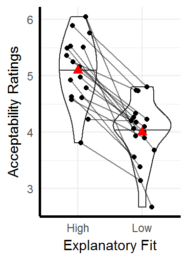

```r
p1_paper
```

We also do not find a single case for which participants mean scores do not agree with the intended ones:

```r
agg1a <- agg1 %>%
  select(-Confident, -Fit2) %>%
  spread(Fit, Accepts)
any(agg1a$High < agg1a$Low)
```

```
## [1] FALSE
```

Confidence ratings are highly correlated with the acceptability scores.

```r
cor.test(~Confident+Accepts, agg1)
```

```
##
##  Pearson's product-moment correlation
##
## data:  Confident and Accepts
## t = 5.2029, df = 34, p-value = 9.369e-06
## alternative hypothesis: true correlation is not equal to 0
## 95 percent confidence interval:
##  0.4316617 0.8158600
## sample estimates:
##       cor
## 0.6657791
```

Given the strong relationship between the two ratings we only consider the `Accepts` rating in the following to avoid multicolinearity.

# Eye-Tracking Data

We analysed four processing measures:

- First pass reading time is the sum of all the fixation durations in seconds from the eye first entering the region until first exiting either to the left or right.
- First pass regressions out is the percentage of trials in which regressive saccades were made from the current most rightward fixation into an earlier region.
- Regression path reading time is the sum of all fixation durations in seconds from the eye first entering a region until first exiting the region to the right (including all re-reading of previously read text).
- Total reading time is the sum of all fixation durations in a region in seconds.

The first two measures provide information about processing as a region of text is first encountered, the third information about both early and intermediate processing, and the fourth information about early, intermediate, and later processes.

Note that the maximal models for the continuous independent variable `Accepts` have by-participant random slopes for `Accepts`, but by-item random slopes for `Fit` (which is the binary experimenter defined fit variable). The reason for this is that `Accepts` has only two different values for each `Item`, thus the binary `Fit` (i.e., a factor) variable seems more reasonable then a continuous variable with two values.

# First Pass Reading Times

```r
data_in <- read.csv("FPs_plus_ratings.csv")
data_in$P.s <- factor(data_in$P.s)
data_in$Item <- factor(data_in$Item)
drp_r <- droplevels(data_in[data_in$Item != "9" ,])
nas <- is.na(drp_r$spillover) | is.na(drp_r$Consequent)
drp_r <- droplevels(drp_r[!nas,])
```

```r
drp_fp <- drp_r %>%
  mutate(
    consequent = Consequent/1000,
    log_con = log(consequent),
    spillover = spillover/1000,
    log_spill = log(spillover))
```

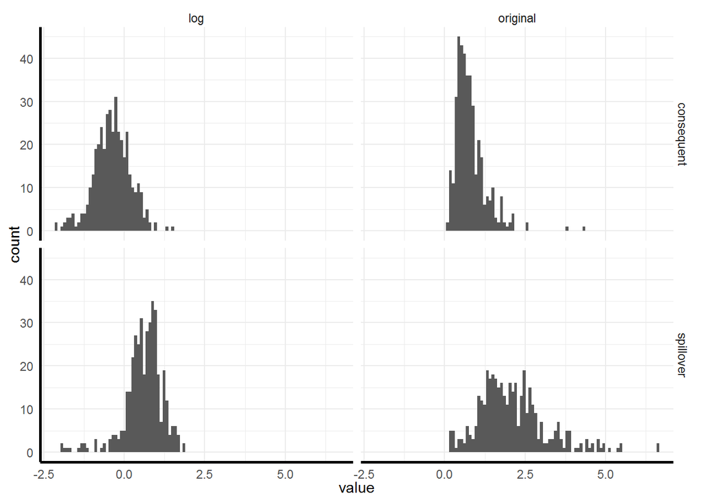

```r
dplot <- drp_fp %>%
  gather("key", "value",consequent, log_con, spillover, log_spill) %>%
  mutate(region = if_else(str_detect(key, "spill"), "spillover", "consequent"),
         type = if_else(str_detect(key, "^log"), "log",
                        if_else(str_detect(key, "^inv"), "inverse", "original")))

ggplot(data = dplot) +
  geom_histogram(mapping = aes(x = value), bins = 100) +
  facet_grid(region ~ type)
```

As can be seen, the log transformation helps quite a bit in achieving approximate normality for the consequent DV, but less for the spillover DV. For the `spillover` variable the untransformed DV may work better. For the untransformed values there are quite a few DVs above 5 seconds (consequent = 0, spillover = 0.02), above 3 seconds (consequent = 0.01, spillover = 0.16) or above 2.5 seconds (consequent = 0.01, spillover = 0.29).

## Consequent

### With Accepts (log-transformed RTs)

We use log-transofmred RTs as DV, and non-transformed acceptability measures as IV.

```r
m_fp_con_21 <- mixed(log_con ~ Accepts + (Accepts|P.s) + (Fit| Item), drp_fp, progress = FALSE)
```

```
## Contrasts set to contr.sum for the following variables: P.s, Fit, Item
```

```
## Numerical variables NOT centered on 0 (i.e., interpretation of all main effects might be difficult if in interactions): Accepts
```

```r
summary(m_fp_con_21)
```

```
## Linear mixed model fit by REML ['merModLmerTest']
## Formula: log_con ~ Accepts + (Accepts | P.s) + (Fit | Item)
##    Data: drp_fp
##
## REML criterion at convergence: 601
##
## Scaled residuals:
##     Min      1Q  Median      3Q     Max
## -3.9697 -0.4829  0.0309  0.6003  3.8365
##
## Random effects:
##  Groups   Name        Variance  Std.Dev. Corr
##  P.s      (Intercept) 0.0156643 0.12516
##           Accepts     0.0004369 0.02090  1.00
##  Item     (Intercept) 0.0505503 0.22483
##           Fit1        0.0004422 0.02103  -1.00
##  Residual             0.2219747 0.47114
## Number of obs: 396, groups:  P.s, 24; Item, 17
##
## Fixed effects:
##             Estimate Std. Error t value
## (Intercept) -0.24617    0.18360  -1.341
## Accepts     -0.02822    0.03610  -0.782
##
## Correlation of Fixed Effects:
##         (Intr)
## Accepts -0.915
```

Because the correlations among the random effects are at the boundary of the parameter space (which indaicted non-identifiability), we remove those.

```r
m_fp_con_22 <- mixed(log_con ~ Accepts + (Accepts||P.s) + (Fit||Item), drp_fp, expand_re = TRUE, progress = FALSE)
```

```
## Contrasts set to contr.sum for the following variables: P.s, Fit, Item
```

```
## Numerical variables NOT centered on 0 (i.e., interpretation of all main effects might be difficult if in interactions): Accepts
```

```r
summary(m_fp_con_22)
```

```
## Linear mixed model fit by REML ['merModLmerTest']
## Formula:
## log_con ~ Accepts + ((1 | P.s) + (0 + re1.Accepts | P.s)) + ((1 |
##     Item) + (0 + re2.Fit1 | Item))
##    Data: drp_fp
##
## REML criterion at convergence: 601.9
##
## Scaled residuals:
##     Min      1Q  Median      3Q     Max
## -3.9777 -0.4691  0.0285  0.6068  3.8170
##
## Random effects:
##  Groups   Name        Variance  Std.Dev.
##  P.s      (Intercept) 0.0350138 0.18712
##  P.s.1    re1.Accepts 0.0006022 0.02454
##  Item     (Intercept) 0.0507219 0.22522
##  Item.1   re2.Fit1    0.0000000 0.00000
##  Residual             0.2226016 0.47181
## Number of obs: 396, groups:  P.s, 24; Item, 17
##
## Fixed effects:
##             Estimate Std. Error t value
## (Intercept) -0.26456    0.17554  -1.507
## Accepts     -0.02457    0.03573  -0.688
##
## Correlation of Fixed Effects:
##         (Intr)
## Accepts -0.906
```

Now we remove the random slope that is estimated to be zero.

```r
m_fp_con_23 <- mixed(log_con ~ Accepts + (Accepts||P.s) + (1|Item), drp_fp, expand_re = TRUE, progress = FALSE)
```

```
## Contrasts set to contr.sum for the following variables: P.s, Item
```

```
## Numerical variables NOT centered on 0 (i.e., interpretation of all main effects might be difficult if in interactions): Accepts
```

```r
summary(m_fp_con_23)
```

```
## Linear mixed model fit by REML ['merModLmerTest']
## Formula: log_con ~ Accepts + ((1 | P.s) + (0 + re1.Accepts | P.s)) + (1 |
##     Item)
##    Data: drp_fp
##
## REML criterion at convergence: 601.9
##
## Scaled residuals:
##     Min      1Q  Median      3Q     Max
## -3.9777 -0.4691  0.0285  0.6068  3.8170
##
## Random effects:
##  Groups   Name        Variance  Std.Dev.
##  P.s      (Intercept) 0.0350141 0.18712
##  P.s.1    re1.Accepts 0.0006021 0.02454
##  Item     (Intercept) 0.0507219 0.22522
##  Residual             0.2226016 0.47181
## Number of obs: 396, groups:  P.s, 24; Item, 17
##
## Fixed effects:
##             Estimate Std. Error t value
## (Intercept) -0.26456    0.17554  -1.507
## Accepts     -0.02457    0.03573  -0.688
##
## Correlation of Fixed Effects:
##         (Intr)
## Accepts -0.906
```

Just to be on the safe side, we also remove the other random slope as it is almost zero.

```r
m_fp_con_24 <- mixed(log_con ~ Accepts + (1|P.s) + (1|Item), drp_fp, expand_re = FALSE, progress = FALSE)
```

```
## Contrasts set to contr.sum for the following variables: P.s, Item
```

```
## Numerical variables NOT centered on 0 (i.e., interpretation of all main effects might be difficult if in interactions): Accepts
```

```r
summary(m_fp_con_24)
```

```
## Linear mixed model fit by REML ['merModLmerTest']
## Formula: log_con ~ Accepts + (1 | P.s) + (1 | Item)
##    Data: drp_fp
##
## REML criterion at convergence: 602
##
## Scaled residuals:
##     Min      1Q  Median      3Q     Max
## -3.9493 -0.4734  0.0236  0.6074  3.8183
##
## Random effects:
##  Groups   Name        Variance Std.Dev.
##  P.s      (Intercept) 0.04814  0.2194
##  Item     (Intercept) 0.05081  0.2254
##  Residual             0.22276  0.4720
## Number of obs: 396, groups:  P.s, 24; Item, 17
##
## Fixed effects:
##             Estimate Std. Error t value
## (Intercept) -0.25930    0.17702  -1.465
## Accepts     -0.02573    0.03536  -0.728
##
## Correlation of Fixed Effects:
##         (Intr)
## Accepts -0.907
```

```r
anova(m_fp_con_21, m_fp_con_22, m_fp_con_23, m_fp_con_24)
```

```
## Data: drp_fp
## Models:
## m_fp_con_24: log_con ~ Accepts + (1 | P.s) + (1 | Item)
## m_fp_con_23: log_con ~ Accepts + ((1 | P.s) + (0 + re1.Accepts | P.s)) + (1 |
## m_fp_con_23:     Item)
## m_fp_con_22: log_con ~ Accepts + ((1 | P.s) + (0 + re1.Accepts | P.s)) + ((1 |
## m_fp_con_22:     Item) + (0 + re2.Fit1 | Item))
## m_fp_con_21: log_con ~ Accepts + (Accepts | P.s) + (Fit | Item)
##             Df    AIC    BIC  logLik deviance  Chisq Chi Df Pr(>Chisq)
## m_fp_con_24  5 612.00 631.91 -301.00   602.00
## m_fp_con_23  6 613.94 637.83 -300.97   601.94 0.0597      1     0.8070
## m_fp_con_22  7 615.94 643.81 -300.97   601.94 0.0000      1     1.0000
## m_fp_con_21  9 619.02 654.85 -300.51   601.02 0.9221      2     0.6306
```

There is some difference between the maximal and the reduced models, but the drop in fit is only minimal. Thus, the optimal model is the random-intercepts only model `m_fp_con_24`. However, both the maximal model and the optimal model show a problematic pattern in their QQ-plots.

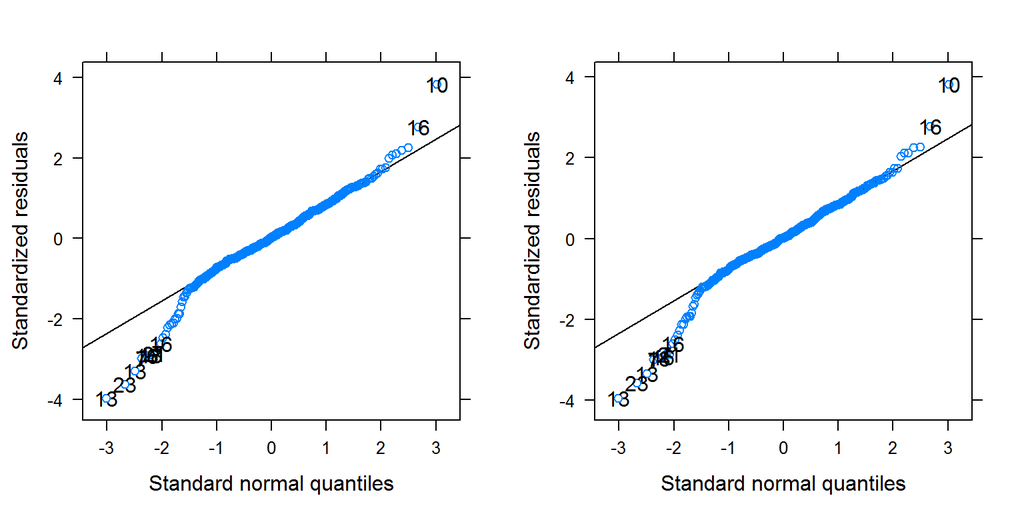

```r
qqp_21 <- qqmath(m_fp_con_21$full_model, id = 0.01, idLabels = as.character(drp_fp$P.s))
qqp_22 <- qqmath(m_fp_con_24$full_model, id = 0.01, idLabels = as.character(drp_fp$P.s))
grid.arrange(qqp_21, qqp_22, ncol = 2)
```

```r
optimal_con_fp <- m_fp_con_24
```

There are a few outliers for long RT, one for participant with ID 16 and one more extreme outlier for participant with ID 10. In addition, there are several outliers for fast RTs.

However, neither model shows a significant effect of `Accepts`.

```r
nice(m_fp_con_21)
```

```
## Mixed Model Anova Table (Type 3 tests, KR-method)
##
## Model: log_con ~ Accepts + (Accepts | P.s) + (Fit | Item)
## Data: drp_fp
##    Effect       df    F p.value
## 1 Accepts 1, 12.72 0.56     .47
## ---
## Signif. codes:  0 '***' 0.001 '**' 0.01 '*' 0.05 '+' 0.1 ' ' 1
```

```r
nice(m_fp_con_22)
```

```
## Mixed Model Anova Table (Type 3 tests, KR-method)
##
## Model: log_con ~ Accepts + (Accepts || P.s) + (Fit || Item)
## Data: drp_fp
##    Effect       df    F p.value
## 1 Accepts 1, 17.31 0.45     .51
## ---
## Signif. codes:  0 '***' 0.001 '**' 0.01 '*' 0.05 '+' 0.1 ' ' 1
```

```r
nice(m_fp_con_23)
```

```
## Mixed Model Anova Table (Type 3 tests, KR-method)
##
## Model: log_con ~ Accepts + (Accepts || P.s) + (1 | Item)
## Data: drp_fp
##    Effect        df    F p.value
## 1 Accepts 1, 231.42 0.46     .50
## ---
## Signif. codes:  0 '***' 0.001 '**' 0.01 '*' 0.05 '+' 0.1 ' ' 1
```

```r
nice(m_fp_con_24)
```

```
## Mixed Model Anova Table (Type 3 tests, KR-method)
##
## Model: log_con ~ Accepts + (1 | P.s) + (1 | Item)
## Data: drp_fp
##    Effect        df    F p.value
## 1 Accepts 1, 362.78 0.52     .47
## ---
## Signif. codes:  0 '***' 0.001 '**' 0.01 '*' 0.05 '+' 0.1 ' ' 1
```

### With Accepts (Lambert transformed RTs)

To address the remaining misfit we attempt a different approach. First we remove a few (4) RTs above 2.5 seconds. Then we apply the Lambert transformation to normalize the data (following Goerg, 2011).

```r
drp_fp_r1 <- drp_fp[drp_fp$consequent < 2.5,]
drp_fp_r1$consequentw <- as.vector(LambertW::Gaussianize(drp_fp_r1$consequent,
                                                        type = "h", method = "MLE"))
```

```r
m_con_lambert_a_1 <- mixed(consequentw ~ Accepts + (Accepts|P.s) + (Fit| Item), drp_fp_r1, progress = FALSE)
```

```
## Contrasts set to contr.sum for the following variables: P.s, Fit, Item
```

```
## Numerical variables NOT centered on 0 (i.e., interpretation of all main effects might be difficult if in interactions): Accepts
```

```r
summary(m_con_lambert_a_1)
```

```
## Linear mixed model fit by REML ['merModLmerTest']
## Formula: consequentw ~ Accepts + (Accepts | P.s) + (Fit | Item)
##    Data: drp_fp_r1
##
## REML criterion at convergence: 162.5
##
## Scaled residuals:
##     Min      1Q  Median      3Q     Max
## -3.4410 -0.5935 -0.1274  0.6040  2.8165
##
## Random effects:
##  Groups   Name        Variance  Std.Dev. Corr
##  P.s      (Intercept) 5.893e-03 0.076763
##           Accepts     2.730e-04 0.016522 1.00
##  Item     (Intercept) 2.024e-02 0.142284
##           Fit1        5.892e-05 0.007676 -1.00
##  Residual             7.126e-02 0.266939
## Number of obs: 392, groups:  P.s, 24; Item, 17
##
## Fixed effects:
##              Estimate Std. Error t value
## (Intercept)  0.794482   0.104333   7.615
## Accepts     -0.009394   0.020625  -0.455
##
## Correlation of Fixed Effects:
##         (Intr)
## Accepts -0.887
```

We again remove the correlations among the random effects.

```r
m_con_lambert_a_2 <- mixed(consequentw ~ Accepts + (Accepts||P.s) + (Fit|| Item), drp_fp_r1, progress = FALSE, expand_re = TRUE)
```

```
## Contrasts set to contr.sum for the following variables: P.s, Fit, Item
```

```
## Numerical variables NOT centered on 0 (i.e., interpretation of all main effects might be difficult if in interactions): Accepts
```

```r
summary(m_con_lambert_a_2)
```

```
## Linear mixed model fit by REML ['merModLmerTest']
## Formula: consequentw ~ Accepts + ((1 | P.s) + (0 + re1.Accepts | P.s)) +
##     ((1 | Item) + (0 + re2.Fit1 | Item))
##    Data: drp_fp_r1
##
## REML criterion at convergence: 163
##
## Scaled residuals:
##     Min      1Q  Median      3Q     Max
## -3.4573 -0.5899 -0.1359  0.5994  2.8339
##
## Random effects:
##  Groups   Name        Variance  Std.Dev.
##  P.s      (Intercept) 0.0119907 0.1095
##  P.s.1    re1.Accepts 0.0005106 0.0226
##  Item     (Intercept) 0.0202467 0.1423
##  Item.1   re2.Fit1    0.0000000 0.0000
##  Residual             0.0713039 0.2670
## Number of obs: 392, groups:  P.s, 24; Item, 17
##
## Fixed effects:
##              Estimate Std. Error t value
## (Intercept)  0.788313   0.101694   7.752
## Accepts     -0.007998   0.020767  -0.385
##
## Correlation of Fixed Effects:
##         (Intr)
## Accepts -0.882
```

We remove the by-item random slope.

```r
m_con_lambert_a_3 <- mixed(consequentw ~ Accepts + (Accepts||P.s) + (1| Item), drp_fp_r1, progress = FALSE, expand_re = TRUE)
```

```
## Contrasts set to contr.sum for the following variables: P.s, Item
```

```
## Numerical variables NOT centered on 0 (i.e., interpretation of all main effects might be difficult if in interactions): Accepts
```

```r
summary(m_con_lambert_a_3)
```

```
## Linear mixed model fit by REML ['merModLmerTest']
## Formula: consequentw ~ Accepts + ((1 | P.s) + (0 + re1.Accepts | P.s)) +
##     (1 | Item)
##    Data: drp_fp_r1
##
## REML criterion at convergence: 163
##
## Scaled residuals:
##     Min      1Q  Median      3Q     Max
## -3.4573 -0.5899 -0.1359  0.5994  2.8339
##
## Random effects:
##  Groups   Name        Variance  Std.Dev.
##  P.s      (Intercept) 0.0119907 0.1095
##  P.s.1    re1.Accepts 0.0005106 0.0226
##  Item     (Intercept) 0.0202467 0.1423
##  Residual             0.0713039 0.2670
## Number of obs: 392, groups:  P.s, 24; Item, 17
##
## Fixed effects:
##              Estimate Std. Error t value
## (Intercept)  0.788313   0.101694   7.752
## Accepts     -0.007998   0.020767  -0.385
##
## Correlation of Fixed Effects:
##         (Intr)
## Accepts -0.882
```

And we remove the by-participant random slope.

```r
m_con_lambert_a_4 <- mixed(consequentw ~ Accepts + (1|P.s) + (1| Item), drp_fp_r1, progress = FALSE, expand_re = FALSE)
```

```
## Contrasts set to contr.sum for the following variables: P.s, Item
```

```
## Numerical variables NOT centered on 0 (i.e., interpretation of all main effects might be difficult if in interactions): Accepts
```

```r
summary(m_con_lambert_a_4)
```

```
## Linear mixed model fit by REML ['merModLmerTest']
## Formula: consequentw ~ Accepts + (1 | P.s) + (1 | Item)
##    Data: drp_fp_r1
##
## REML criterion at convergence: 163.4
##
## Scaled residuals:
##     Min      1Q  Median      3Q     Max
## -3.3710 -0.5971 -0.1300  0.6183  2.8836
##
## Random effects:
##  Groups   Name        Variance Std.Dev.
##  P.s      (Intercept) 0.02301  0.1517
##  Item     (Intercept) 0.02032  0.1425
##  Residual             0.07148  0.2674
## Number of obs: 392, groups:  P.s, 24; Item, 17
##
## Fixed effects:
##              Estimate Std. Error t value
## (Intercept)  0.793578   0.103907   7.637
## Accepts     -0.009149   0.020235  -0.452
##
## Correlation of Fixed Effects:
##         (Intr)
## Accepts -0.885
```

```r
anova(m_con_lambert_a_1, m_con_lambert_a_2, m_con_lambert_a_3, m_con_lambert_a_4)
```

```
## Data: drp_fp_r1
## Models:
## m_con_lambert_a_4: consequentw ~ Accepts + (1 | P.s) + (1 | Item)
## m_con_lambert_a_3: consequentw ~ Accepts + ((1 | P.s) + (0 + re1.Accepts | P.s)) +
## m_con_lambert_a_3:     (1 | Item)
## m_con_lambert_a_2: consequentw ~ Accepts + ((1 | P.s) + (0 + re1.Accepts | P.s)) +
## m_con_lambert_a_2:     ((1 | Item) + (0 + re2.Fit1 | Item))
## m_con_lambert_a_1: consequentw ~ Accepts + (Accepts | P.s) + (Fit | Item)
##                   Df    AIC    BIC  logLik deviance  Chisq Chi Df
## m_con_lambert_a_4  5 173.42 193.28 -81.710   163.42
## m_con_lambert_a_3  6 175.05 198.87 -81.523   163.05 0.3737      1
## m_con_lambert_a_2  7 177.05 204.85 -81.523   163.05 0.0000      1
## m_con_lambert_a_1  9 180.48 216.22 -81.239   162.48 0.5688      2
##                   Pr(>Chisq)
## m_con_lambert_a_4
## m_con_lambert_a_3     0.5410
## m_con_lambert_a_2     1.0000
## m_con_lambert_a_1     0.7524
```

The optimal model again appears to be the random-intercept only model (`m_con_lambert_a_4`). In addition, the QQ-plots show only mild violations.

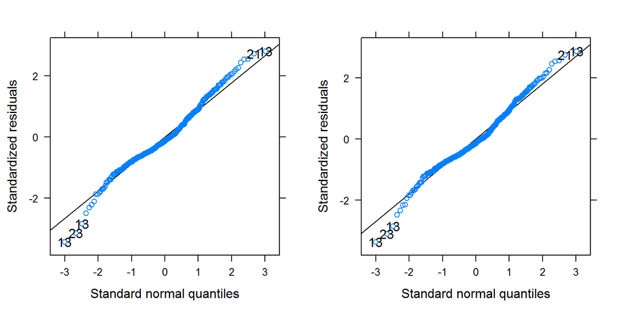

```r
qqp_21 <- qqmath(m_con_lambert_a_1$full_model, id = 0.01, idLabels = as.character(drp_fp_r1$P.s))
qqp_22 <- qqmath(m_con_lambert_a_4$full_model, id = 0.01, idLabels = as.character(drp_fp_r1$P.s))
grid.arrange(qqp_21, qqp_22, ncol = 2)
```

Furthermore, neither model shows a significant effect of `Accepts`.

```r
nice(m_con_lambert_a_1)
```

```
## Mixed Model Anova Table (Type 3 tests, KR-method)
##
## Model: consequentw ~ Accepts + (Accepts | P.s) + (Fit | Item)
## Data: drp_fp_r1
##    Effect       df    F p.value
## 1 Accepts 1, 12.47 0.19     .67
## ---
## Signif. codes:  0 '***' 0.001 '**' 0.01 '*' 0.05 '+' 0.1 ' ' 1
```

```r
nice(m_con_lambert_a_2)
```

```
## Mixed Model Anova Table (Type 3 tests, KR-method)
##
## Model: consequentw ~ Accepts + (Accepts || P.s) + (Fit || Item)
## Data: drp_fp_r1
##    Effect       df    F p.value
## 1 Accepts 1, 17.68 0.14     .71
## ---
## Signif. codes:  0 '***' 0.001 '**' 0.01 '*' 0.05 '+' 0.1 ' ' 1
```

```r
nice(m_con_lambert_a_3)
```

```
## Mixed Model Anova Table (Type 3 tests, KR-method)
##
## Model: consequentw ~ Accepts + (Accepts || P.s) + (1 | Item)
## Data: drp_fp_r1
##    Effect        df    F p.value
## 1 Accepts 1, 213.49 0.15     .70
## ---
## Signif. codes:  0 '***' 0.001 '**' 0.01 '*' 0.05 '+' 0.1 ' ' 1
```

```r
nice(m_con_lambert_a_4)
```

```
## Mixed Model Anova Table (Type 3 tests, KR-method)
##
## Model: consequentw ~ Accepts + (1 | P.s) + (1 | Item)
## Data: drp_fp_r1
##    Effect        df    F p.value
## 1 Accepts 1, 364.06 0.20     .65
## ---
## Signif. codes:  0 '***' 0.001 '**' 0.01 '*' 0.05 '+' 0.1 ' ' 1
```

## Spillover

### With Accepts (log-transformed RTs)

```r
m_fp_spill_a_1 <- mixed(log_spill ~ Accepts + (Accepts|P.s) + (Fit| Item), drp_fp, progress = FALSE)
```

```
## Contrasts set to contr.sum for the following variables: P.s, Fit, Item
```

```
## Numerical variables NOT centered on 0 (i.e., interpretation of all main effects might be difficult if in interactions): Accepts
```

```r
summary(m_fp_spill_a_1)
```

```
## Linear mixed model fit by REML ['merModLmerTest']
## Formula: log_spill ~ Accepts + (Accepts | P.s) + (Fit | Item)
##    Data: drp_fp
##
## REML criterion at convergence: 652.5
##
## Scaled residuals:
##     Min      1Q  Median      3Q     Max
## -5.0061 -0.2862  0.1525  0.5634  2.4729
##
## Random effects:
##  Groups   Name        Variance  Std.Dev. Corr
##  P.s      (Intercept) 0.6161731 0.78497
##           Accepts     0.0135825 0.11654  -1.00
##  Item     (Intercept) 0.0353376 0.18798
##           Fit1        0.0001198 0.01094  1.00
##  Residual             0.2537492 0.50374
## Number of obs: 396, groups:  P.s, 24; Item, 17
##
## Fixed effects:
##             Estimate Std. Error t value
## (Intercept)  0.48851    0.23597   2.070
## Accepts      0.02709    0.04418   0.613
##
## Correlation of Fixed Effects:
##         (Intr)
## Accepts -0.956
```

Again we observe large correlations among the random-effects parameters and we refit the model without these correlations.

```r
m_fp_spill_a_2 <- mixed(log_spill ~ Accepts + (Accepts||P.s) + (Fit||Item), drp_fp, expand_re = TRUE, progress = FALSE)
```

```
## Contrasts set to contr.sum for the following variables: P.s, Fit, Item
```

```
## Numerical variables NOT centered on 0 (i.e., interpretation of all main effects might be difficult if in interactions): Accepts
```

```r
summary(m_fp_spill_a_2)
```

```
## Linear mixed model fit by REML ['merModLmerTest']
## Formula: log_spill ~ Accepts + ((1 | P.s) + (0 + re1.Accepts | P.s)) +
##     ((1 | Item) + (0 + re2.Fit1 | Item))
##    Data: drp_fp
##
## REML criterion at convergence: 662
##
## Scaled residuals:
##     Min      1Q  Median      3Q     Max
## -4.9430 -0.3133  0.1508  0.5388  2.3542
##
## Random effects:
##  Groups   Name        Variance Std.Dev.
##  P.s      (Intercept) 0.06563  0.2562
##  P.s.1    re1.Accepts 0.00000  0.0000
##  Item     (Intercept) 0.03270  0.1808
##  Item.1   re2.Fit1    0.00000  0.0000
##  Residual             0.26274  0.5126
## Number of obs: 396, groups:  P.s, 24; Item, 17
##
## Fixed effects:
##             Estimate Std. Error t value
## (Intercept)  0.45506    0.18548   2.454
## Accepts      0.03465    0.03755   0.923
##
## Correlation of Fixed Effects:
##         (Intr)
## Accepts -0.919
```

The by-item and by-participant random slopes are now estimated at zero, we consequently refit the models without these parameters.

```r
m_fp_spill_a_3 <- mixed(log_spill ~ Accepts + (1|P.s) + (1| Item), drp_fp, expand_re = FALSE, progress = FALSE)
```

```
## Contrasts set to contr.sum for the following variables: P.s, Item
```

```
## Numerical variables NOT centered on 0 (i.e., interpretation of all main effects might be difficult if in interactions): Accepts
```

```r
summary(m_fp_spill_a_3)
```

```
## Linear mixed model fit by REML ['merModLmerTest']
## Formula: log_spill ~ Accepts + (1 | P.s) + (1 | Item)
##    Data: drp_fp
##
## REML criterion at convergence: 662
##
## Scaled residuals:
##     Min      1Q  Median      3Q     Max
## -4.9430 -0.3133  0.1508  0.5388  2.3542
##
## Random effects:
##  Groups   Name        Variance Std.Dev.
##  P.s      (Intercept) 0.06563  0.2562
##  Item     (Intercept) 0.03270  0.1808
##  Residual             0.26274  0.5126
## Number of obs: 396, groups:  P.s, 24; Item, 17
##
## Fixed effects:
##             Estimate Std. Error t value
## (Intercept)  0.45506    0.18548   2.454
## Accepts      0.03465    0.03755   0.923
##
## Correlation of Fixed Effects:
##         (Intr)
## Accepts -0.919
```

Removing the correlation strangely leads to a considerable drop in fit. Hence, the optimal models is the maximal model.

```r
anova(m_fp_spill_a_1, m_fp_spill_a_2, m_fp_spill_a_3)
```

```
## Data: drp_fp
## Models:
## m_fp_spill_a_3: log_spill ~ Accepts + (1 | P.s) + (1 | Item)
## m_fp_spill_a_2: log_spill ~ Accepts + ((1 | P.s) + (0 + re1.Accepts | P.s)) +
## m_fp_spill_a_2:     ((1 | Item) + (0 + re2.Fit1 | Item))
## m_fp_spill_a_1: log_spill ~ Accepts + (Accepts | P.s) + (Fit | Item)
##                Df    AIC    BIC  logLik deviance  Chisq Chi Df Pr(>Chisq)
## m_fp_spill_a_3  5 672.02 691.93 -331.01   662.02
## m_fp_spill_a_2  7 676.02 703.89 -331.01   662.02 0.0000      2   1.000000
## m_fp_spill_a_1  9 670.46 706.29 -326.23   652.46 9.5596      2   0.008398
##
## m_fp_spill_a_3
## m_fp_spill_a_2
## m_fp_spill_a_1 **
## ---
## Signif. codes:  0 '***' 0.001 '**' 0.01 '*' 0.05 '.' 0.1 ' ' 1
```

```r
optimal_spill_fp <- m_fp_spill_a_1
```

The QQ-plot of both models again shows strong departarue from normality for fast RTs.

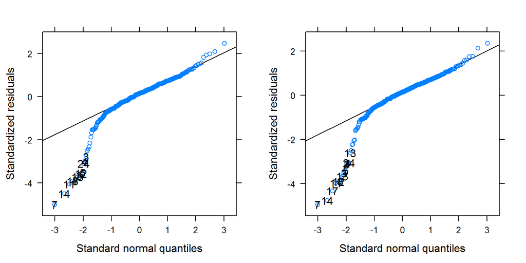

```r
qqp_m1 <- qqmath(m_fp_spill_a_1$full_model, id = 0.01, idLabels = as.character(drp_r$P.s))
qqp_m2 <- qqmath(m_fp_spill_a_3$full_model, id = 0.01, idLabels = as.character(drp_r$P.s))
grid.arrange(qqp_m1, qqp_m2, ncol = 2)
```

However, the effect of `Accepts` is not significant.

```r
nice(m_fp_spill_a_1)
```

```
## Mixed Model Anova Table (Type 3 tests, KR-method)
##
## Model: log_spill ~ Accepts + (Accepts | P.s) + (Fit | Item)
## Data: drp_fp
##    Effect       df    F p.value
## 1 Accepts 1, 17.11 0.35     .56
## ---
## Signif. codes:  0 '***' 0.001 '**' 0.01 '*' 0.05 '+' 0.1 ' ' 1
```

```r
nice(m_fp_spill_a_2)
```

```
## Mixed Model Anova Table (Type 3 tests, KR-method)
##
## Model: log_spill ~ Accepts + (Accepts || P.s) + (Fit || Item)
## Data: drp_fp
##    Effect       df    F p.value
## 1 Accepts 1, 17.85 0.80     .38
## ---
## Signif. codes:  0 '***' 0.001 '**' 0.01 '*' 0.05 '+' 0.1 ' ' 1
```

```r
nice(m_fp_spill_a_3)
```

```
## Mixed Model Anova Table (Type 3 tests, KR-method)
##
## Model: log_spill ~ Accepts + (1 | P.s) + (1 | Item)
## Data: drp_fp
##    Effect        df    F p.value
## 1 Accepts 1, 330.04 0.83     .36
## ---
## Signif. codes:  0 '***' 0.001 '**' 0.01 '*' 0.05 '+' 0.1 ' ' 1
```

## With Accept (Lambert-transformed RTs)

Due to the large misfit, we again try the Lambert transformation after removing 3 RTs we identified as outliers (based on preliminary analysis not reported here).

```r
out_spill <- (drp_fp$P.s == "14" & drp_fp$spillover < 0.5 ) |
  (drp_fp$P.s == "23" & drp_fp$spillover > 6.0 )
drp_fp_r2 <- drp_fp[!out_spill,]
#drp_fp_r2 <- drp_fp
drp_fp_r2$spilloverw <- as.vector(LambertW::Gaussianize(drp_fp_r2$spillover,
                                                        type = "h", method = "MLE"))
```

Due to the large misfit, we again try the Lambert transformation on the reduced data set.

```r
m_fp_spill_lambert_a_1 <- mixed(spilloverw ~ Accepts + (Accepts|P.s) + (Fit| Item), drp_fp_r2, progress = FALSE)
```

```
## Contrasts set to contr.sum for the following variables: P.s, Fit, Item
```

```
## Numerical variables NOT centered on 0 (i.e., interpretation of all main effects might be difficult if in interactions): Accepts
```

```r
summary(m_fp_spill_lambert_a_1)
```

```
## Linear mixed model fit by REML ['merModLmerTest']
## Formula: spilloverw ~ Accepts + (Accepts | P.s) + (Fit | Item)
##    Data: drp_fp_r2
##
## REML criterion at convergence: 856.7
##
## Scaled residuals:
##     Min      1Q  Median      3Q     Max
## -3.2630 -0.5557 -0.0315  0.5849  3.0430
##
## Random effects:
##  Groups   Name        Variance  Std.Dev. Corr
##  P.s      (Intercept) 0.6109655 0.78164
##           Accepts     0.0034631 0.05885  -1.00
##  Item     (Intercept) 0.1251616 0.35378
##           Fit1        0.0002333 0.01527  1.00
##  Residual             0.4040268 0.63563
## Number of obs: 393, groups:  P.s, 24; Item, 17
##
## Fixed effects:
##             Estimate Std. Error t value
## (Intercept)  1.88430    0.28192   6.684
## Accepts      0.04404    0.05035   0.875
##
## Correlation of Fixed Effects:
##         (Intr)
## Accepts -0.872
```

Due to the large correlations between the random-effects parameters we refit the model without the correlations.

```r
m_fp_spill_lambert_a_2 <- mixed(spilloverw ~ Accepts + (Accepts||P.s) + (Fit || Item), drp_fp_r2, progress = FALSE, expand_re = TRUE)
```

```
## Contrasts set to contr.sum for the following variables: P.s, Fit, Item
```

```
## Numerical variables NOT centered on 0 (i.e., interpretation of all main effects might be difficult if in interactions): Accepts
```

```r
summary(m_fp_spill_lambert_a_2)
```

```
## Linear mixed model fit by REML ['merModLmerTest']
## Formula: spilloverw ~ Accepts + ((1 | P.s) + (0 + re1.Accepts | P.s)) +
##     ((1 | Item) + (0 + re2.Fit1 | Item))
##    Data: drp_fp_r2
##
## REML criterion at convergence: 858.3
##
## Scaled residuals:
##     Min      1Q  Median      3Q     Max
## -3.2509 -0.5413 -0.0487  0.6026  2.9556
##
## Random effects:
##  Groups   Name        Variance Std.Dev.
##  P.s      (Intercept) 0.2678   0.5175
##  P.s.1    re1.Accepts 0.0000   0.0000
##  Item     (Intercept) 0.1232   0.3510
##  Item.1   re2.Fit1    0.0000   0.0000
##  Residual             0.4060   0.6372
## Number of obs: 393, groups:  P.s, 24; Item, 17
##
## Fixed effects:
##             Estimate Std. Error t value
## (Intercept)  1.85832    0.26170   7.101
## Accepts      0.04958    0.04879   1.016
##
## Correlation of Fixed Effects:
##         (Intr)
## Accepts -0.846
```

Now both random slopes are estimated to be zero, we consequently refit the model without those parameters.

```r
m_fp_spill_lambert_a_3 <- mixed(spilloverw ~ Accepts + (1|P.s) + (1| Item), drp_fp_r2, progress = FALSE, expand_re = FALSE)
```

```
## Contrasts set to contr.sum for the following variables: P.s, Item
```

```
## Numerical variables NOT centered on 0 (i.e., interpretation of all main effects might be difficult if in interactions): Accepts
```

```r
summary(m_fp_spill_lambert_a_3)
```

```
## Linear mixed model fit by REML ['merModLmerTest']
## Formula: spilloverw ~ Accepts + (1 | P.s) + (1 | Item)
##    Data: drp_fp_r2
##
## REML criterion at convergence: 858.3
##
## Scaled residuals:
##     Min      1Q  Median      3Q     Max
## -3.2509 -0.5413 -0.0487  0.6026  2.9556
##
## Random effects:
##  Groups   Name        Variance Std.Dev.
##  P.s      (Intercept) 0.2678   0.5175
##  Item     (Intercept) 0.1232   0.3510
##  Residual             0.4060   0.6372
## Number of obs: 393, groups:  P.s, 24; Item, 17
##
## Fixed effects:
##             Estimate Std. Error t value
## (Intercept)  1.85832    0.26170   7.101
## Accepts      0.04958    0.04879   1.016
##
## Correlation of Fixed Effects:
##         (Intr)
## Accepts -0.846
```

This time the final model appears to be the optimal model.

```r
anova(m_fp_spill_lambert_a_1, m_fp_spill_lambert_a_2, m_fp_spill_lambert_a_3)
```

```
## Data: drp_fp_r2
## Models:
## m_fp_spill_lambert_a_3: spilloverw ~ Accepts + (1 | P.s) + (1 | Item)
## m_fp_spill_lambert_a_2: spilloverw ~ Accepts + ((1 | P.s) + (0 + re1.Accepts | P.s)) +
## m_fp_spill_lambert_a_2:     ((1 | Item) + (0 + re2.Fit1 | Item))
## m_fp_spill_lambert_a_1: spilloverw ~ Accepts + (Accepts | P.s) + (Fit | Item)
##                        Df    AIC    BIC  logLik deviance  Chisq Chi Df
## m_fp_spill_lambert_a_3  5 868.28 888.14 -429.14   858.28
## m_fp_spill_lambert_a_2  7 872.28 900.09 -429.14   858.28 0.0000      2
## m_fp_spill_lambert_a_1  9 874.67 910.43 -428.33   856.67 1.6093      2
##                        Pr(>Chisq)
## m_fp_spill_lambert_a_3
## m_fp_spill_lambert_a_2     1.0000
## m_fp_spill_lambert_a_1     0.4472
```

The QQ-plot now only shows comparatively mild violations at the edges. However, for the low RTs they still appear to large.

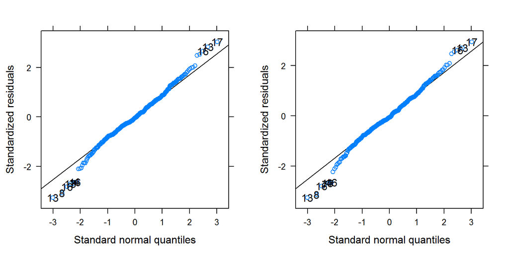

```r
qqp_m1 <- qqmath(m_fp_spill_lambert_a_1$full_model, id = 0.01, idLabels = as.character(drp_fp_r2$P.s))
qqp_m2 <- qqmath(m_fp_spill_lambert_a_3$full_model, id = 0.01, idLabels = as.character(drp_fp_r2$P.s))
grid.arrange(qqp_m1, qqp_m2, ncol = 2)
```

```r
nice(m_fp_spill_lambert_a_1)
```

```
## Mixed Model Anova Table (Type 3 tests, KR-method)
##
## Model: spilloverw ~ Accepts + (Accepts | P.s) + (Fit | Item)
## Data: drp_fp_r2
##    Effect       df    F p.value
## 1 Accepts 1, 13.10 0.71     .41
## ---
## Signif. codes:  0 '***' 0.001 '**' 0.01 '*' 0.05 '+' 0.1 ' ' 1
```

```r
nice(m_fp_spill_lambert_a_3)
```

```
## Mixed Model Anova Table (Type 3 tests, KR-method)
##
## Model: spilloverw ~ Accepts + (1 | P.s) + (1 | Item)
## Data: drp_fp_r2
##    Effect        df    F p.value
## 1 Accepts 1, 365.98 1.02     .31
## ---
## Signif. codes:  0 '***' 0.001 '**' 0.01 '*' 0.05 '+' 0.1 ' ' 1
```

# First pass Regression Outs

The goal of the following analysis was to see whether the explanatory goodness of fit would affect the DVs. For detailed analysis of the IVs see other file.

```r
data_in <- read.csv("RO_plus_ratings.csv")
data_in$P.s <- factor(data_in$P.s)
data_in$Item <- factor(data_in$Item)
```

## Data Preparation

```r
drp_ro <- droplevels(data_in[data_in$Item != "9" ,])
nas <- is.na(drp_ro$spillover) | is.na(drp_ro$Consequent)
drp_ro <- droplevels(drp_ro[!nas,])
```

For the analysis we remove 0 trials with missing data in either spillover or Consequent.

## Consequent

```r
m_con_a_1 <- mixed(Consequent ~ Accepts + (Accepts|P.s) + (Fit| Item), drp_ro, family = binomial, method = "LRT", progress = FALSE)
```

```
## Contrasts set to contr.sum for the following variables: P.s, Fit, Item
```

```
## Numerical variables NOT centered on 0 (i.e., interpretation of all main effects might be difficult if in interactions): Accepts
```

```r
summary(m_con_a_1)
```

```
## Generalized linear mixed model fit by maximum likelihood (Laplace
##   Approximation) [glmerMod]
##  Family: binomial  ( logit )
## Formula: Consequent ~ Accepts + (Accepts | P.s) + (Fit | Item)
##    Data: drp_ro
##
##      AIC      BIC   logLik deviance df.resid
##    372.0    404.1   -178.0    356.0      400
##
## Scaled residuals:
##     Min      1Q  Median      3Q     Max
## -1.1335 -0.4400 -0.3546 -0.2716  3.5300
##
## Random effects:
##  Groups Name        Variance Std.Dev. Corr
##  P.s    (Intercept) 3.77024  1.9417
##         Accepts     0.09836  0.3136   -1.00
##  Item   (Intercept) 0.29283  0.5411
##         Fit1        0.01766  0.1329   -0.50
## Number of obs: 408, groups:  P.s, 24; Item, 17
##
## Fixed effects:
##             Estimate Std. Error z value Pr(>|z|)
## (Intercept)   0.0835     1.3591   0.061    0.951
## Accepts      -0.4164     0.2926  -1.423    0.155
##
## Correlation of Fixed Effects:
##         (Intr)
## Accepts -0.984
## convergence code: 0
## Model failed to converge with max|grad| = 0.00165609 (tol = 0.001, component 1)
```

We see a suspcisouly high correlations between the by-participant random effect parameters, consequently we remove it.

```r
m_con_a_2 <- mixed(Consequent ~ Accepts + (Accepts||P.s) + (Fit|Item), drp_ro, family = binomial, method = "LRT", progress = FALSE, expand_re = TRUE, all_fit = TRUE)
```

```
## Contrasts set to contr.sum for the following variables: P.s, Fit, Item
```

```
## Numerical variables NOT centered on 0 (i.e., interpretation of all main effects might be difficult if in interactions): Accepts
```

```r
summary(m_con_a_2)
```

```
## Generalized linear mixed model fit by maximum likelihood (Laplace
##   Approximation) [glmerMod]
##  Family: binomial  ( logit )
## Formula:
## Consequent ~ Accepts + (1 + re1.Accepts || P.s) + (1 + re2.Fit1 |
##     Item)
##    Data: drp_ro
##
##      AIC      BIC   logLik deviance df.resid
##    371.3    399.4   -178.7    357.3      401
##
## Scaled residuals:
##     Min      1Q  Median      3Q     Max
## -0.9442 -0.4616 -0.3636 -0.2610  3.8257
##
## Random effects:
##  Groups Name        Variance Std.Dev. Corr
##  P.s    (Intercept) 0.27424  0.5237
##  P.s.1  re1.Accepts 0.00000  0.0000
##  Item   (Intercept) 0.25281  0.5028
##         re2.Fit1    0.03405  0.1845   -0.06
## Number of obs: 408, groups:  P.s, 24; Item, 17
##
## Fixed effects:
##             Estimate Std. Error z value Pr(>|z|)
## (Intercept)   0.7018     1.1637   0.603   0.5465
## Accepts      -0.5536     0.2598  -2.131   0.0331 *
## ---
## Signif. codes:  0 '***' 0.001 '**' 0.01 '*' 0.05 '.' 0.1 ' ' 1
##
## Correlation of Fixed Effects:
##         (Intr)
## Accepts -0.979
```

Given the small estimate of the by-participant random slope we remove it.

```r
m_con_a_3 <- mixed(Consequent ~ Accepts + (1|P.s) + (Fit|Item), drp_ro, family = binomial, method = "LRT", progress = FALSE, expand_re = FALSE, all_fit = TRUE)
```

```
## Contrasts set to contr.sum for the following variables: P.s, Fit, Item
```

```
## Numerical variables NOT centered on 0 (i.e., interpretation of all main effects might be difficult if in interactions): Accepts
```

```r
summary(m_con_a_3)
```

```
## Generalized linear mixed model fit by maximum likelihood (Laplace
##   Approximation) [glmerMod]
##  Family: binomial  ( logit )
## Formula: Consequent ~ Accepts + (1 | P.s) + (Fit | Item)
##    Data: drp_ro
## Control: ctrl
##
##      AIC      BIC   logLik deviance df.resid
##    369.3    393.4   -178.7    357.3      402
##
## Scaled residuals:
##     Min      1Q  Median      3Q     Max
## -0.9442 -0.4616 -0.3636 -0.2610  3.8258
##
## Random effects:
##  Groups Name        Variance Std.Dev. Corr
##  P.s    (Intercept) 0.27424  0.5237
##  Item   (Intercept) 0.25280  0.5028
##         Fit1        0.03405  0.1845   -0.06
## Number of obs: 408, groups:  P.s, 24; Item, 17
##
## Fixed effects:
##             Estimate Std. Error z value Pr(>|z|)
## (Intercept)   0.7018     1.1637   0.603   0.5465
## Accepts      -0.5536     0.2598  -2.131   0.0331 *
## ---
## Signif. codes:  0 '***' 0.001 '**' 0.01 '*' 0.05 '.' 0.1 ' ' 1
##
## Correlation of Fixed Effects:
##         (Intr)
## Accepts -0.979
```

```r
anova(m_con_a_1, m_con_a_2, m_con_a_3)
```

```
## Data: drp_ro
## Models:
## m_con_a_3: Consequent ~ Accepts + (1 | P.s) + (Fit | Item)
## m_con_a_2: Consequent ~ Accepts + (1 + re1.Accepts || P.s) + (1 + re2.Fit1 |
## m_con_a_2:     Item)
## m_con_a_1: Consequent ~ Accepts + (Accepts | P.s) + (Fit | Item)
##           Df    AIC    BIC  logLik deviance  Chisq Chi Df Pr(>Chisq)
## m_con_a_3  6 369.32 393.39 -178.66   357.32
## m_con_a_2  7 371.32 399.40 -178.66   357.32 0.0000      1     1.0000
## m_con_a_1  8 372.04 404.13 -178.02   356.04 1.2779      1     0.2583
```

```r
optimal_con_ro <- m_con_a_3
```

Again, the reduced model seems to be the optimal model. Consequently we also inspect the residuals of this model. Overall this also looks very reasonable.

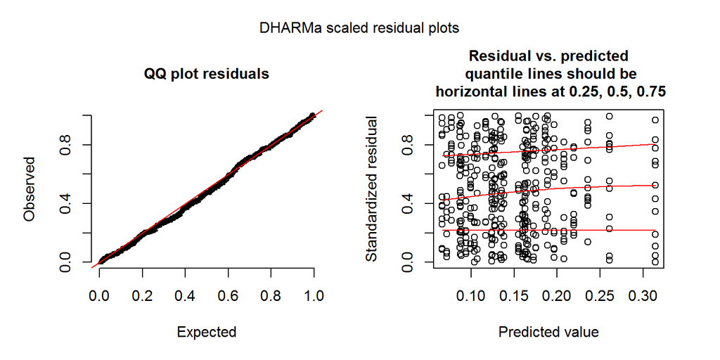

```r
sim_m_con_a_3 <- simulateResiduals(fittedModel = m_con_a_3$full_model, n = 500)
plotSimulatedResiduals(sim_m_con_a_3)
```

For the optimal model we find a significant effect of `Accepts`.

```r
nice(m_con_a_1)
```

```
## Mixed Model Anova Table (Type 3 tests, LRT-method)
##
## Model: Consequent ~ Accepts + (Accepts | P.s) + (Fit | Item)
## Data: drp_ro
## Df full model: 8
##    Effect df Chisq p.value
## 1 Accepts  1  2.14     .14
## ---
## Signif. codes:  0 '***' 0.001 '**' 0.01 '*' 0.05 '+' 0.1 ' ' 1
```

```r
nice(m_con_a_3)
```

```
## Mixed Model Anova Table (Type 3 tests, LRT-method)
##
## Model: Consequent ~ Accepts + (1 | P.s) + (Fit | Item)
## Data: drp_ro
## Df full model: 6
##    Effect df  Chisq p.value
## 1 Accepts  1 4.70 *     .03
## ---
## Signif. codes:  0 '***' 0.001 '**' 0.01 '*' 0.05 '+' 0.1 ' ' 1
```

## With Accepts (non-transformed)

```r
m_spill_a_1 <- mixed(spillover ~ Accepts + (Accepts|P.s) + (Fit| Item), drp_ro, family = binomial, method = "LRT", progress = FALSE)
```

```
## Contrasts set to contr.sum for the following variables: P.s, Fit, Item
```

```
## Numerical variables NOT centered on 0 (i.e., interpretation of all main effects might be difficult if in interactions): Accepts
```

```r
summary(m_spill_a_1)
```

```
## Generalized linear mixed model fit by maximum likelihood (Laplace
##   Approximation) [glmerMod]
##  Family: binomial  ( logit )
## Formula: spillover ~ Accepts + (Accepts | P.s) + (Fit | Item)
##    Data: drp_ro
##
##      AIC      BIC   logLik deviance df.resid
##    556.3    588.4   -270.2    540.3      400
##
## Scaled residuals:
##     Min      1Q  Median      3Q     Max
## -1.7103 -0.8108 -0.5362  0.8784  2.0383
##
## Random effects:
##  Groups Name        Variance Std.Dev. Corr
##  P.s    (Intercept) 2.455457 1.56699
##         Accepts     0.177474 0.42128  -0.95
##  Item   (Intercept) 0.058626 0.24213
##         Fit1        0.006947 0.08335  -1.00
## Number of obs: 408, groups:  P.s, 24; Item, 17
##
## Fixed effects:
##             Estimate Std. Error z value Pr(>|z|)
## (Intercept)   1.5035     0.7803   1.927   0.0540 .
## Accepts      -0.3714     0.1759  -2.111   0.0348 *
## ---
## Signif. codes:  0 '***' 0.001 '**' 0.01 '*' 0.05 '.' 0.1 ' ' 1
##
## Correlation of Fixed Effects:
##         (Intr)
## Accepts -0.973
## convergence code: 0
## Model failed to converge with max|grad| = 0.00181203 (tol = 0.001, component 1)
```

We observe extreme correlations between the by-item random-effects parameters and we refit the model without the correlation.

```r
m_spill_a_2 <- mixed(spillover ~ Accepts + (Accepts|P.s) + (Fit|| Item), drp_ro, family = binomial, method = "LRT", progress = FALSE, expand_re = TRUE)
```

```
## Contrasts set to contr.sum for the following variables: P.s, Fit, Item
```

```
## Numerical variables NOT centered on 0 (i.e., interpretation of all main effects might be difficult if in interactions): Accepts
```

```r
summary(m_spill_a_2)
```

```
## Generalized linear mixed model fit by maximum likelihood (Laplace
##   Approximation) [glmerMod]
##  Family: binomial  ( logit )
## Formula: spillover ~ Accepts + (1 + re1.Accepts | P.s) + (1 + re2.Fit1 ||
##     Item)
##    Data: drp_ro
##
##      AIC      BIC   logLik deviance df.resid
##    554.7    582.7   -270.3    540.7      401
##
## Scaled residuals:
##     Min      1Q  Median      3Q     Max
## -1.7512 -0.8280 -0.5315  0.8754  1.9998
##
## Random effects:
##  Groups Name        Variance Std.Dev. Corr
##  P.s    (Intercept) 2.45179  1.5658
##         re1.Accepts 0.17915  0.4233   -0.95
##  Item   (Intercept) 0.05177  0.2275
##  Item.1 re2.Fit1    0.00000  0.0000
## Number of obs: 408, groups:  P.s, 24; Item, 17
##
## Fixed effects:
##             Estimate Std. Error z value Pr(>|z|)
## (Intercept)   1.5650     0.7597   2.060   0.0394 *
## Accepts      -0.3827     0.1738  -2.202   0.0277 *
## ---
## Signif. codes:  0 '***' 0.001 '**' 0.01 '*' 0.05 '.' 0.1 ' ' 1
##
## Correlation of Fixed Effects:
##         (Intr)
## Accepts -0.973
```

As one random slopes is estimated to be zero, we consequently refit the model without this parameter.

```r
m_spill_a_3 <- mixed(spillover ~ Accepts + (Accepts|P.s) + (1| Item), drp_ro, family = binomial, method = "LRT", progress = FALSE, expand_re = TRUE)
```

```
## Contrasts set to contr.sum for the following variables: P.s, Item
```

```
## Numerical variables NOT centered on 0 (i.e., interpretation of all main effects might be difficult if in interactions): Accepts
```

```r
summary(m_spill_a_3)
```

```
## Generalized linear mixed model fit by maximum likelihood (Laplace
##   Approximation) [glmerMod]
##  Family: binomial  ( logit )
## Formula: spillover ~ Accepts + (1 + re1.Accepts | P.s) + (1 | Item)
##    Data: drp_ro
##
##      AIC      BIC   logLik deviance df.resid
##    552.7    576.7   -270.3    540.7      402
##
## Scaled residuals:
##     Min      1Q  Median      3Q     Max
## -1.7512 -0.8280 -0.5315  0.8754  1.9998
##
## Random effects:
##  Groups Name        Variance Std.Dev. Corr
##  P.s    (Intercept) 2.45171  1.5658
##         re1.Accepts 0.17915  0.4233   -0.95
##  Item   (Intercept) 0.05177  0.2275
## Number of obs: 408, groups:  P.s, 24; Item, 17
##
## Fixed effects:
##             Estimate Std. Error z value Pr(>|z|)
## (Intercept)   1.5650     0.7597   2.060   0.0394 *
## Accepts      -0.3827     0.1738  -2.202   0.0277 *
## ---
## Signif. codes:  0 '***' 0.001 '**' 0.01 '*' 0.05 '.' 0.1 ' ' 1
##
## Correlation of Fixed Effects:
##         (Intr)
## Accepts -0.973
```

This model seems reasonable and only provides a minimally worse account than the first model.

```r
anova(m_spill_a_1, m_spill_a_3)
```

```
## Data: drp_ro
## Models:
## m_spill_a_3: spillover ~ Accepts + (1 + re1.Accepts | P.s) + (1 | Item)
## m_spill_a_1: spillover ~ Accepts + (Accepts | P.s) + (Fit | Item)
##             Df    AIC    BIC  logLik deviance  Chisq Chi Df Pr(>Chisq)
## m_spill_a_3  6 552.65 576.72 -270.33   540.65
## m_spill_a_1  8 556.34 588.43 -270.17   540.34 0.3157      2      0.854
```

```r
optimal_spill_ro <- m_spill_a_3
```

No issue with the diagnostic plots.

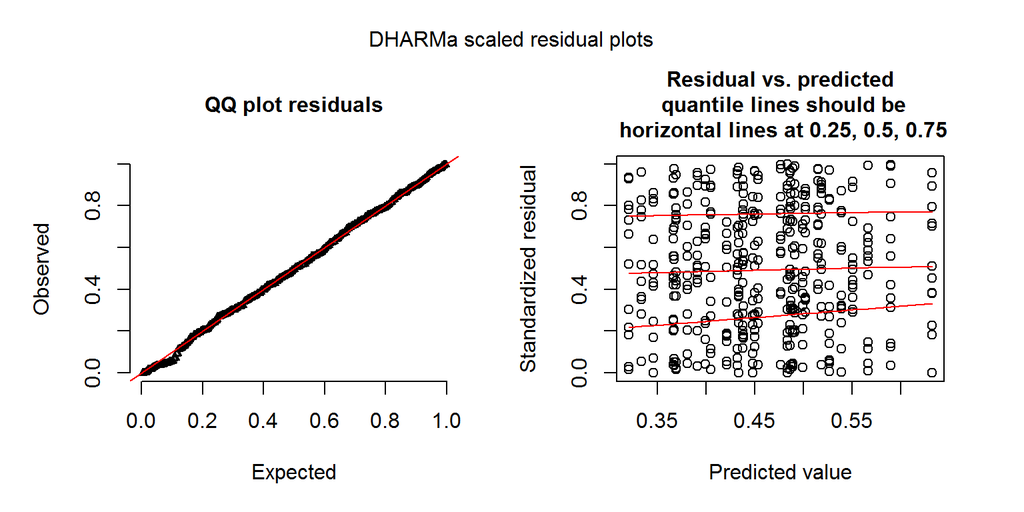

```r
sim_m_spill_a_3 <- simulateResiduals(fittedModel = m_spill_a_3$full_model, n = 500)
plotSimulatedResiduals(sim_m_spill_a_3)
```

```r
nice(m_spill_a_1)
```

```
## Mixed Model Anova Table (Type 3 tests, LRT-method)
##
## Model: spillover ~ Accepts + (Accepts | P.s) + (Fit | Item)
## Data: drp_ro
## Df full model: 8
##    Effect df  Chisq p.value
## 1 Accepts  1 4.20 *     .04
## ---
## Signif. codes:  0 '***' 0.001 '**' 0.01 '*' 0.05 '+' 0.1 ' ' 1
```

```r
nice(m_spill_a_3)
```

```
## Mixed Model Anova Table (Type 3 tests, LRT-method)
##
## Model: spillover ~ Accepts + (Accepts | P.s) + (1 | Item)
## Data: drp_ro
## Df full model: 6
##    Effect df  Chisq p.value
## 1 Accepts  1 4.76 *     .03
## ---
## Signif. codes:  0 '***' 0.001 '**' 0.01 '*' 0.05 '+' 0.1 ' ' 1
```

# Regression Path Times

## Data Preparation

```r
drp_r <- droplevels(RPs_plus_ratings[RPs_plus_ratings$Item != "9" ,])
nas <- is.na(drp_r$spillover) | is.na(drp_r$Consequent)
drp_r <- droplevels(drp_r[!nas,])
```

For the analysis we remove 13 trials with missing data in either spillover or Consequent. Then we transform all RTs from ms to s and calculate transformed versions using `log`.

```r
drp_rp <- drp_r %>%
  mutate(
    consequent = Consequent/1000,
    log_con = log(consequent),
    spillover = spillover/1000,
    log_spill = log(spillover)
  )
```

We then plot the different versions of the DVs.

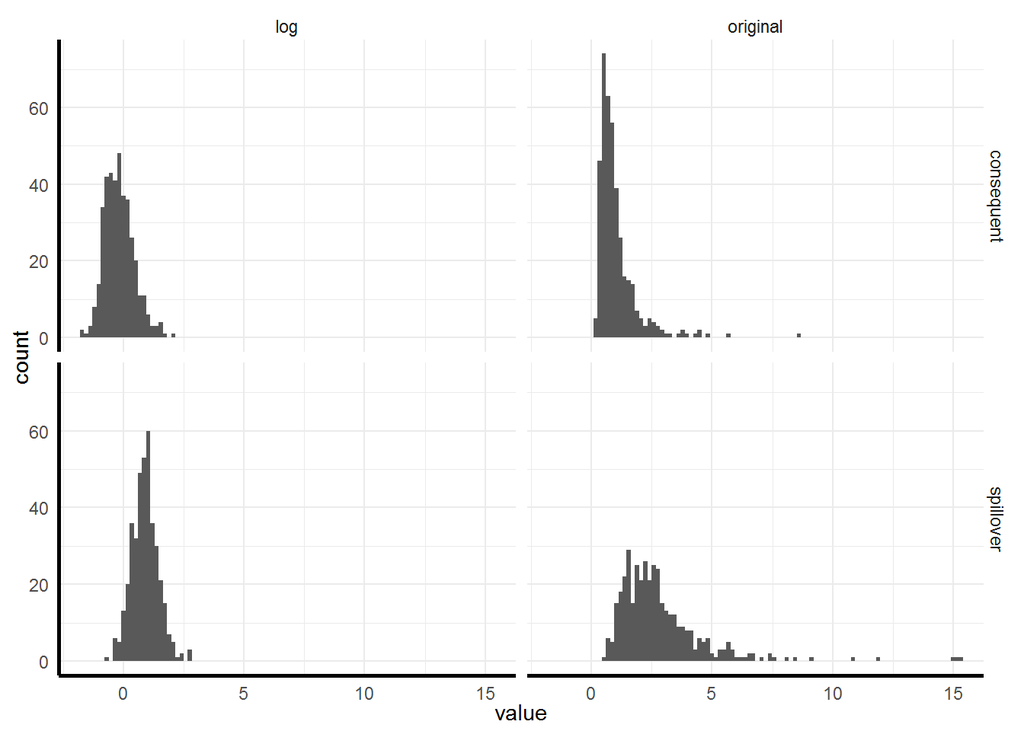

```r
dplot <- drp_rp %>%
  gather("key", "value",consequent, log_con, spillover, log_spill) %>%
  mutate(region = if_else(str_detect(key, "spill"), "spillover", "consequent"),
         type = if_else(str_detect(key, "^log"), "log",
                        if_else(str_detect(key, "^inv"), "inverse", "original")))

ggplot(data = dplot) +
  geom_histogram(mapping = aes(x = value), bins = 100) +
  facet_grid(region ~ type)
```

As can be seen, the log transformation helps quite a bit in achieving approximate normality. Especially the `spillover` variable otherwise exhibits clearly a number of extreme values such as RTs above 5 seconds (consequent = 0.01, spillover = 0.09), above 3 seconds (consequent = 0.03, spillover = 0.32) or above 2.5 seconds (consequent = 0.05, spillover = 0.48).

## Consequent

We use log-transofmred RTs as DV, and non-transformed acceptability measures as IV.

```r
m_fp_con_21 <- mixed(log_con ~ Accepts + (Accepts|P.s) + (Fit| Item), drp_rp, progress = FALSE)
```

```
## Contrasts set to contr.sum for the following variables: P.s, Fit, Item
```

```
## Numerical variables NOT centered on 0 (i.e., interpretation of all main effects might be difficult if in interactions): Accepts
```

```r
summary(m_fp_con_21)
```

```
## Linear mixed model fit by REML ['merModLmerTest']
## Formula: log_con ~ Accepts + (Accepts | P.s) + (Fit | Item)
##    Data: drp_rp
##
## REML criterion at convergence: 645.4
##
## Scaled residuals:
##     Min      1Q  Median      3Q     Max
## -2.3567 -0.5711 -0.1720  0.5095  4.3072
##
## Random effects:
##  Groups   Name        Variance Std.Dev. Corr
##  P.s      (Intercept) 0.268086 0.51777
##           Accepts     0.015545 0.12468  -0.88
##  Item     (Intercept) 0.052133 0.22833
##           Fit1        0.001039 0.03223  1.00
##  Residual             0.239569 0.48946
## Number of obs: 395, groups:  P.s, 24; Item, 17
##
## Fixed effects:
##             Estimate Std. Error t value
## (Intercept)  0.36258    0.20095   1.804
## Accepts     -0.11691    0.04604  -2.539
##
## Correlation of Fixed Effects:
##         (Intr)
## Accepts -0.921
```

We see a suspcisouly high correlation between the by-item random-effects parameters, consequently we remove those.

```r
m_fp_con_22 <- mixed(log_con ~ Accepts + (Accepts|P.s) + (Fit||Item), drp_rp, expand_re = TRUE, progress = FALSE)
```

```
## Contrasts set to contr.sum for the following variables: P.s, Fit, Item
```

```
## Numerical variables NOT centered on 0 (i.e., interpretation of all main effects might be difficult if in interactions): Accepts
```

```r
summary(m_fp_con_22)
```

```
## Linear mixed model fit by REML ['merModLmerTest']
## Formula: log_con ~ Accepts + (1 + re1.Accepts | P.s) + ((1 | Item) + (0 +
##     re2.Fit1 | Item))
##    Data: drp_rp
##
## REML criterion at convergence: 646.7
##
## Scaled residuals:
##     Min      1Q  Median      3Q     Max
## -2.3861 -0.5708 -0.1517  0.5101  4.2845
##
## Random effects:
##  Groups   Name        Variance Std.Dev. Corr
##  P.s      (Intercept) 0.27441  0.52384
##           re1.Accepts 0.01590  0.12608  -0.88
##  Item     (Intercept) 0.05206  0.22816
##  Item.1   re2.Fit1    0.00037  0.01923
##  Residual             0.24001  0.48991
## Number of obs: 395, groups:  P.s, 24; Item, 17
##
## Fixed effects:
##             Estimate Std. Error t value
## (Intercept)  0.34115    0.21109   1.616
## Accepts     -0.11298    0.04576  -2.469
##
## Correlation of Fixed Effects:
##         (Intr)
## Accepts -0.923
```

```r
anova(m_fp_con_21, m_fp_con_22)
```

```
## Data: drp_rp
## Models:
## m_fp_con_22: log_con ~ Accepts + (1 + re1.Accepts | P.s) + ((1 | Item) + (0 +
## m_fp_con_22:     re2.Fit1 | Item))
## m_fp_con_21: log_con ~ Accepts + (Accepts | P.s) + (Fit | Item)
##             Df    AIC    BIC  logLik deviance  Chisq Chi Df Pr(>Chisq)
## m_fp_con_22  8 662.68 694.51 -323.34   646.68
## m_fp_con_21  9 663.38 699.19 -322.69   645.38 1.2964      1     0.2549
```

```r
optimal_con_rp <- m_fp_con_22
```

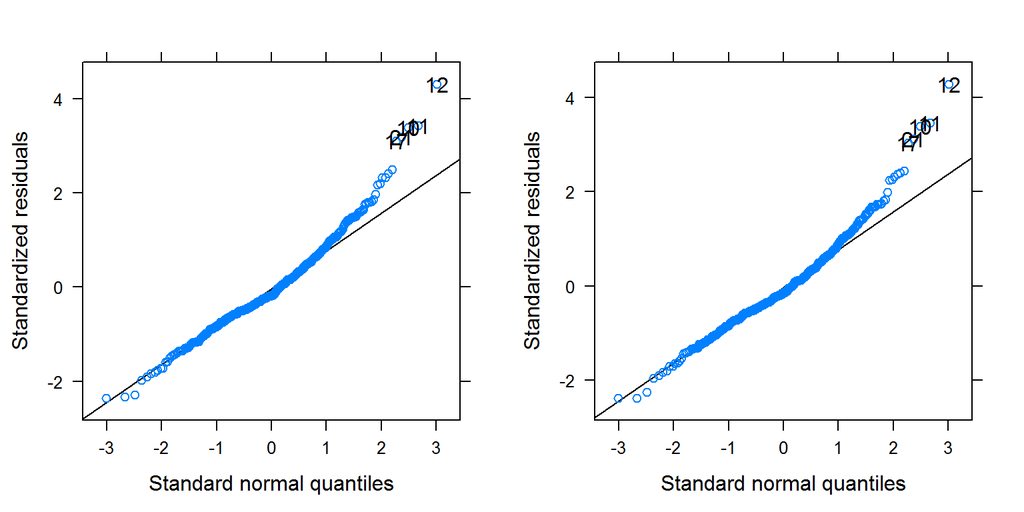

```r
qqp_21 <- qqmath(m_fp_con_21$full_model, id = 0.01, idLabels = as.character(drp_rp$P.s))
qqp_22 <- qqmath(m_fp_con_22$full_model, id = 0.01, idLabels = as.character(drp_rp$P.s))
grid.arrange(qqp_21, qqp_22, ncol = 2)
```

In any case, both models show a significant effect of `Accepts`.

```r
nice(m_fp_con_21)
```

```
## Mixed Model Anova Table (Type 3 tests, KR-method)
##
## Model: log_con ~ Accepts + (Accepts | P.s) + (Fit | Item)
## Data: drp_rp
##    Effect       df      F p.value
## 1 Accepts 1, 18.02 6.00 *     .02
## ---
## Signif. codes:  0 '***' 0.001 '**' 0.01 '*' 0.05 '+' 0.1 ' ' 1
```

```r
nice(m_fp_con_22)
```

```
## Mixed Model Anova Table (Type 3 tests, KR-method)
##
## Model: log_con ~ Accepts + (Accepts | P.s) + (Fit || Item)
## Data: drp_rp
##    Effect       df      F p.value
## 1 Accepts 1, 17.55 5.90 *     .03
## ---
## Signif. codes:  0 '***' 0.001 '**' 0.01 '*' 0.05 '+' 0.1 ' ' 1
```

### Removed RTs

To make sure the long RTs do not have an unreasonable influence on the results we refit the optimal model after removing the RTs that are clear outliers in the qq-plots:

```r
outlier_ids <- c(12, 10, 11, 21, 17)
n_outliers <-  c(1,  1,  2,  1,  1)
outlier_rows <- unlist(lapply(seq_along(outlier_ids), function(x) {
  tmp <- drp_rp[ drp_rp$P.s == outlier_ids[x], "log_con", drop=FALSE ]
  as.numeric(rownames(tmp)[order(tmp, decreasing = TRUE)[seq_len(n_outliers[x])]])
  }))

drp_r2 <- drp_rp[-outlier_rows,]
```

```r
m_fp_con_22_r <- mixed(log_con ~ Accepts + (Accepts|P.s) + (Fit||Item), drp_r2, expand_re = TRUE, progress = FALSE)
```

```
## Contrasts set to contr.sum for the following variables: P.s, Fit, Item
```

```
## Numerical variables NOT centered on 0 (i.e., interpretation of all main effects might be difficult if in interactions): Accepts
```

```r
summary(m_fp_con_22_r)
```

```
## Linear mixed model fit by REML ['merModLmerTest']
## Formula: log_con ~ Accepts + (1 + re1.Accepts | P.s) + ((1 | Item) + (0 +
##     re2.Fit1 | Item))
##    Data: drp_r2
##
## REML criterion at convergence: 558.7
##
## Scaled residuals:
##     Min      1Q  Median      3Q     Max
## -2.5462 -0.5763 -0.1406  0.5673  2.7771
##
## Random effects:
##  Groups   Name        Variance  Std.Dev. Corr
##  P.s      (Intercept) 0.1914667 0.43757
##           re1.Accepts 0.0115014 0.10724  -0.80
##  Item     (Intercept) 0.0540039 0.23239
##  Item.1   re2.Fit1    0.0004319 0.02078
##  Residual             0.1907680 0.43677
## Number of obs: 389, groups:  P.s, 24; Item, 17
##
## Fixed effects:
##             Estimate Std. Error t value
## (Intercept)  0.23775    0.19059   1.247
## Accepts     -0.09638    0.04093  -2.355
##
## Correlation of Fixed Effects:
##         (Intr)
## Accepts -0.897
```

The resulting qq-plots look a lot less problematic:

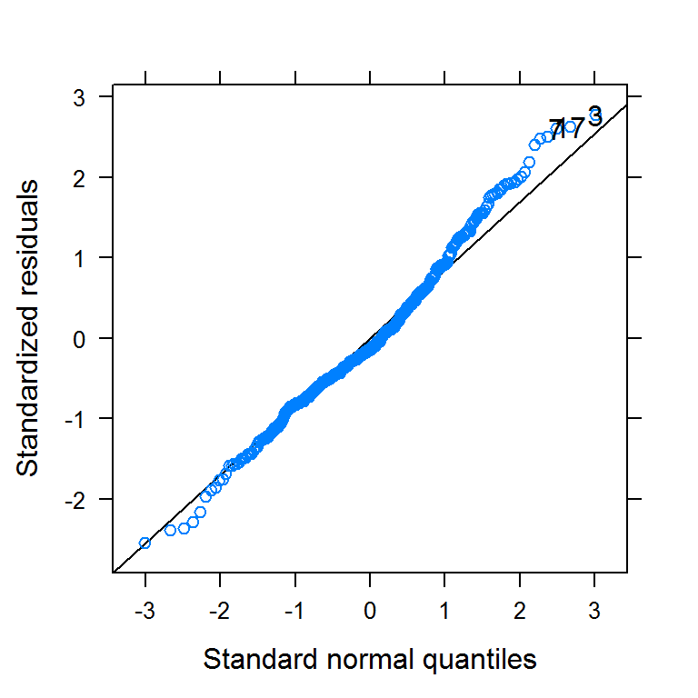

```r
qqp_22 <- qqmath(m_fp_con_22_r$full_model, id = 0.01, idLabels = as.character(drp_r2$P.s))
qqp_22
```

In addition, we still find the effects of Acceptability.

```r
nice(m_fp_con_22_r)
```

```
## Mixed Model Anova Table (Type 3 tests, KR-method)
##
## Model: log_con ~ Accepts + (Accepts | P.s) + (Fit || Item)
## Data: drp_r2
##    Effect       df      F p.value
## 1 Accepts 1, 16.99 5.38 *     .03
## ---
## Signif. codes:  0 '***' 0.001 '**' 0.01 '*' 0.05 '+' 0.1 ' ' 1
```

### Sanity Checks

To make sure our decision to use the logged RTs was justified we also fit the maximal model with the untransformed DVs.

```r
m_fp_con_91 <- mixed(consequent ~ Accepts + (Accepts|P.s) + (Fit| Item), drp_rp, progress = FALSE)
```

```
## Contrasts set to contr.sum for the following variables: P.s, Fit, Item
```

```
## Numerical variables NOT centered on 0 (i.e., interpretation of all main effects might be difficult if in interactions): Accepts
```

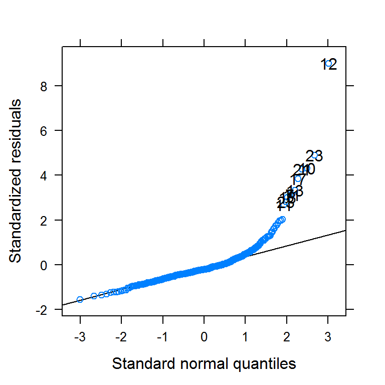

```r
qqp_91 <- qqmath(m_fp_con_91$full_model, id = 0.01, idLabels = as.character(drp_rp$P.s))
qqp_91
```

From the QQ-plot it is obvious that the impact of the outliers is a lot more dramatic for the untransformed RTs than for the models with logged RTs. Consequently, the logged RTs seems to be the most reasonable DV.

## Spillover

```r
m_fp_spill_a_1 <- mixed(log_spill ~ Accepts + (Accepts|P.s) + (Fit| Item), drp_rp, progress = FALSE)
```

```
## Contrasts set to contr.sum for the following variables: P.s, Fit, Item
```

```
## Numerical variables NOT centered on 0 (i.e., interpretation of all main effects might be difficult if in interactions): Accepts
```

```r
summary(m_fp_spill_a_1)
```

```
## Linear mixed model fit by REML ['merModLmerTest']
## Formula: log_spill ~ Accepts + (Accepts | P.s) + (Fit | Item)
##    Data: drp_rp
##
## REML criterion at convergence: 533.8
##
## Scaled residuals:
##     Min      1Q  Median      3Q     Max
## -2.8793 -0.6022 -0.0477  0.6138  3.6575
##
## Random effects:
##  Groups   Name        Variance  Std.Dev. Corr
##  P.s      (Intercept) 0.0190081 0.13787
##           Accepts     0.0006064 0.02463  1.00
##  Item     (Intercept) 0.0553584 0.23528
##           Fit1        0.0003331 0.01825  -1.00
##  Residual             0.1819083 0.42651
## Number of obs: 395, groups:  P.s, 24; Item, 17
##
## Fixed effects:
##             Estimate Std. Error t value
## (Intercept)  1.22852    0.17141   7.167
## Accepts     -0.07264    0.03312  -2.193
##
## Correlation of Fixed Effects:
##         (Intr)
## Accepts -0.887
```

Again we observe correlations at the boundary between the by-participants and by-item random-effects parameters and we refit the model without the correlations.

```r
m_fp_spill_a_2 <- mixed(log_spill ~ Accepts + (Accepts||P.s) + (Fit||Item), drp_rp, expand_re = TRUE, progress = FALSE)
```

```
## Contrasts set to contr.sum for the following variables: P.s, Fit, Item
```

```
## Numerical variables NOT centered on 0 (i.e., interpretation of all main effects might be difficult if in interactions): Accepts
```

```r
summary(m_fp_spill_a_2)
```

```
## Linear mixed model fit by REML ['merModLmerTest']
## Formula: log_spill ~ Accepts + ((1 | P.s) + (0 + re1.Accepts | P.s)) +
##     ((1 | Item) + (0 + re2.Fit1 | Item))
##    Data: drp_rp
##
## REML criterion at convergence: 534.9
##
## Scaled residuals:
##     Min      1Q  Median      3Q     Max
## -2.8093 -0.5766 -0.0520  0.6090  3.6301
##
## Random effects:
##  Groups   Name        Variance Std.Dev.
##  P.s      (Intercept) 0.038722 0.19678
##  P.s.1    re1.Accepts 0.001074 0.03277
##  Item     (Intercept) 0.055750 0.23611
##  Item.1   re2.Fit1    0.000000 0.00000
##  Residual             0.182298 0.42696
## Number of obs: 395, groups:  P.s, 24; Item, 17
##
## Fixed effects:
##             Estimate Std. Error t value
## (Intercept)  1.24366    0.16403   7.582
## Accepts     -0.07607    0.03303  -2.303
##
## Correlation of Fixed Effects:
##         (Intr)
## Accepts -0.876
```

```r
m_fp_spill_a_3 <- mixed(log_spill ~ Accepts + (1|P.s) + (1| Item), drp_rp, progress = FALSE)
```

```
## Contrasts set to contr.sum for the following variables: P.s, Item
```

```
## Numerical variables NOT centered on 0 (i.e., interpretation of all main effects might be difficult if in interactions): Accepts
```

```r
summary(m_fp_spill_a_3)
```

```
## Linear mixed model fit by REML ['merModLmerTest']
## Formula: log_spill ~ Accepts + (1 | P.s) + (1 | Item)
##    Data: drp_rp
##
## REML criterion at convergence: 535
##
## Scaled residuals:
##     Min      1Q  Median      3Q     Max
## -2.8251 -0.5852 -0.0521  0.5998  3.6679
##
## Random effects:
##  Groups   Name        Variance Std.Dev.
##  P.s      (Intercept) 0.06210  0.2492
##  Item     (Intercept) 0.05609  0.2368
##  Residual             0.18260  0.4273
## Number of obs: 395, groups:  P.s, 24; Item, 17
##
## Fixed effects:
##             Estimate Std. Error t value
## (Intercept)  1.25331    0.16694   7.507
## Accepts     -0.07823    0.03232  -2.421
##
## Correlation of Fixed Effects:
##         (Intr)
## Accepts -0.879
```

This model seems reasonable and only provides a minimally worse account than the first model.

```r
anova(m_fp_spill_a_1, m_fp_spill_a_3)
```

```
## Data: drp_rp
## Models:
## m_fp_spill_a_3: log_spill ~ Accepts + (1 | P.s) + (1 | Item)
## m_fp_spill_a_1: log_spill ~ Accepts + (Accepts | P.s) + (Fit | Item)
##                Df    AIC    BIC  logLik deviance  Chisq Chi Df Pr(>Chisq)
## m_fp_spill_a_3  5 545.02 564.92 -267.51   535.02
## m_fp_spill_a_1  9 551.80 587.61 -266.90   533.80 1.2221      4     0.8745
```

```r
optimal_spill_rp <- m_fp_spill_a_3
```

The QQ-plot of both models is essentially identical. Again we see some problems for data from participant 10.

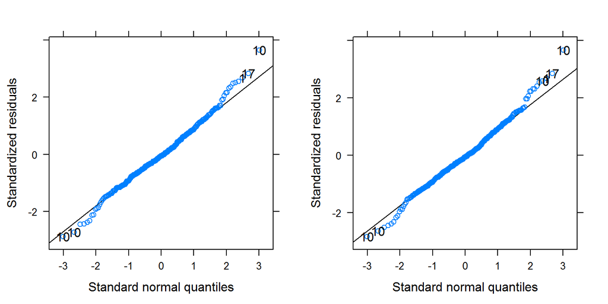

```r
qqp_m1 <- qqmath(m_fp_spill_a_1$full_model, id = 0.01, idLabels = as.character(drp_rp$P.s))
qqp_m2 <- qqmath(m_fp_spill_a_3$full_model, id = 0.01, idLabels = as.character(drp_rp$P.s))
grid.arrange(qqp_m1, qqp_m2, ncol = 2)
```

The effect of `acc_z` now is almost significant for the maximal model (which appears to be overparameterized) and significant for the random-intercepts only model.

```r
nice(m_fp_spill_a_1)
```

```
## Mixed Model Anova Table (Type 3 tests, KR-method)
##
## Model: log_spill ~ Accepts + (Accepts | P.s) + (Fit | Item)
## Data: drp_rp
##    Effect       df      F p.value
## 1 Accepts 1, 12.63 4.44 +     .06
## ---
## Signif. codes:  0 '***' 0.001 '**' 0.01 '*' 0.05 '+' 0.1 ' ' 1
```

```r
nice(m_fp_spill_a_3)
```

```
## Mixed Model Anova Table (Type 3 tests, KR-method)
##
## Model: log_spill ~ Accepts + (1 | P.s) + (1 | Item)
## Data: drp_rp
##    Effect        df      F p.value
## 1 Accepts 1, 368.21 5.78 *     .02
## ---
## Signif. codes:  0 '***' 0.001 '**' 0.01 '*' 0.05 '+' 0.1 ' ' 1
```

### Models Without Participant 10

Finally we also remove the problematic participant 10 and refit the optimal models.

```r
drp_r2 <- droplevels(drp_rp[!(drp_rp$P.s %in% c("10")),])
m_fp_spill_a_3b <- mixed(log_spill ~ Accepts + (1|P.s) + (1| Item), drp_r2, progress = FALSE)
```

```
## Contrasts set to contr.sum for the following variables: P.s, Item
```

```
## Numerical variables NOT centered on 0 (i.e., interpretation of all main effects might be difficult if in interactions): Accepts
```

```r
nice(m_fp_spill_a_3b)
```

```
## Mixed Model Anova Table (Type 3 tests, KR-method)
##
## Model: log_spill ~ Accepts + (1 | P.s) + (1 | Item)
## Data: drp_r2
##    Effect        df      F p.value
## 1 Accepts 1, 353.53 5.95 *     .02
## ---
## Signif. codes:  0 '***' 0.001 '**' 0.01 '*' 0.05 '+' 0.1 ' ' 1
```

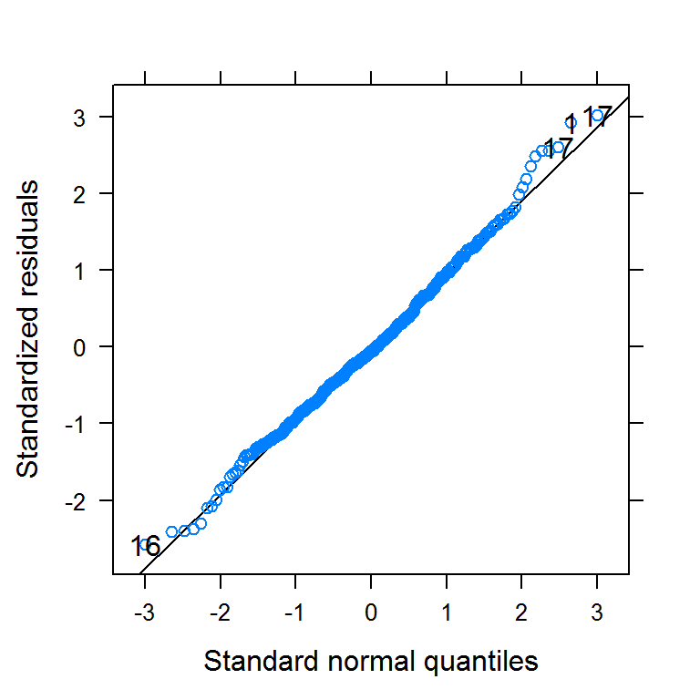

```r
qqp_m3 <- qqmath(m_fp_spill_a_3b$full_model, id = 0.01, idLabels = as.character(drp_r2$P.s))
qqp_m3
```

This analysis shows that the effect of Acceptability is clearly significant is for the two model variants (with logged or untransformed `Accepts` as IV). In addition, the QQ-plots look even less problematic.

# Total Reading Times

```r
data_in <- read.csv("TTs_plus_ratings.csv")
data_in$P.s <- factor(data_in$P.s)
data_in$Item <- factor(data_in$Item)
drp_r <- droplevels(data_in[data_in$Item != "9" ,])
nas <- is.na(drp_r$spillover) | is.na(drp_r$Consequent)
drp_tt <- droplevels(drp_r[!nas,])
```

For the analysis we remove 2 trials with missing data in either spillover or Consequent. Then we transform all RTs from ms to s and calculate transformed versions using the `log` transformation.

```r
drp_tt <- drp_tt %>%
  mutate(
    consequent = Consequent/1000,
    log_con = log(consequent),
    spillover = spillover/1000,
    log_spill = log(spillover)
    )
```

We then plot the two versions of the DVs.

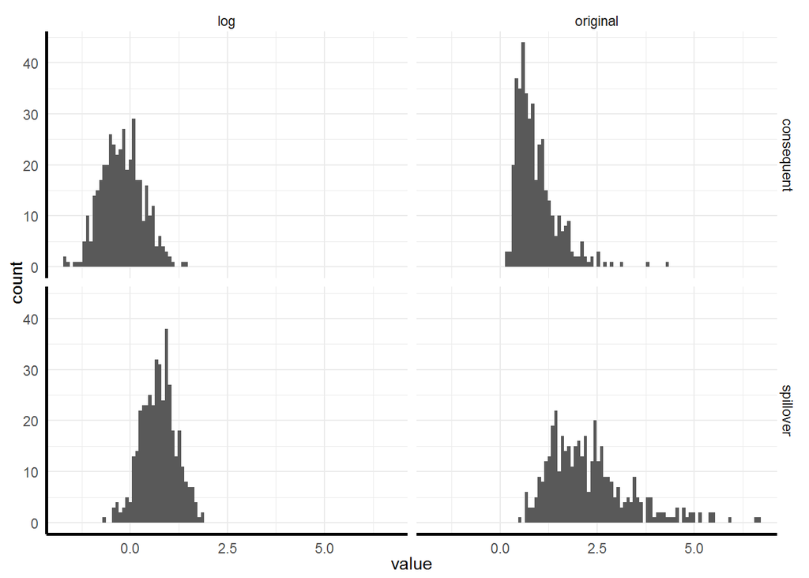

```r
dplot <- drp_tt %>%
  gather("key", "value",consequent, log_con, spillover, log_spill) %>%
  mutate(region = if_else(str_detect(key, "spill"), "spillover", "consequent"),
         type = if_else(str_detect(key, "^log"), "log",
                        if_else(str_detect(key, "^inv"), "inverse", "original")))

ggplot(data = dplot) +
  geom_histogram(mapping = aes(x = value), bins = 100) +
  facet_grid(region ~ type)
```

As can be seen, the log transformation helps quite a bit in achieving approximate normality for both consequent and spillover. However, both DVs seems to have too fat tails. For the `spillover` variable the untransformed DV may work better. For the untransformed values there are quite a few DVs above 5 seconds (consequent = 0, spillover = 0.02), above 3 seconds (consequent = 0.01, spillover = 0.2) or above 2.5 seconds (consequent = 0.02, spillover = 0.34).

## Consequent

### With Accepts (log-transformed RTs)

```r
m_fp_con_21 <- mixed(log_con ~ Accepts + (Accepts|P.s) + (Fit| Item), drp_tt, progress = FALSE)
```

```
## Contrasts set to contr.sum for the following variables: P.s, Fit, Item
```

```
## Numerical variables NOT centered on 0 (i.e., interpretation of all main effects might be difficult if in interactions): Accepts
```

```r
summary(m_fp_con_21)
```

```
## Linear mixed model fit by REML ['merModLmerTest']
## Formula: log_con ~ Accepts + (Accepts | P.s) + (Fit | Item)
##    Data: drp_tt
##
## REML criterion at convergence: 484.2
##
## Scaled residuals:
##     Min      1Q  Median      3Q     Max
## -2.7231 -0.5777 -0.0899  0.5429  4.0243
##
## Random effects:
##  Groups   Name        Variance  Std.Dev. Corr
##  P.s      (Intercept) 0.0372095 0.19290
##           Accepts     0.0068489 0.08276  -0.75
##  Item     (Intercept) 0.0647854 0.25453
##           Fit1        0.0002549 0.01597  1.00
##  Residual             0.1502211 0.38758
## Number of obs: 406, groups:  P.s, 24; Item, 17
##
## Fixed effects:
##             Estimate Std. Error t value
## (Intercept)  0.11102    0.14606   0.760
## Accepts     -0.07162    0.03430  -2.088
##
## Correlation of Fixed Effects:
##         (Intr)
## Accepts -0.847
```

We remove the correlations among the by-item random effects.

```r
m_fp_con_22 <- mixed(log_con ~ Accepts + (Accepts|P.s) + (Fit||Item), drp_tt, expand_re = TRUE, progress = FALSE)
```

```
## Contrasts set to contr.sum for the following variables: P.s, Fit, Item
```

```
## Numerical variables NOT centered on 0 (i.e., interpretation of all main effects might be difficult if in interactions): Accepts
```

```r
summary(m_fp_con_22)
```

```
## Linear mixed model fit by REML ['merModLmerTest']
## Formula: log_con ~ Accepts + (1 + re1.Accepts | P.s) + ((1 | Item) + (0 +
##     re2.Fit1 | Item))
##    Data: drp_tt
##
## REML criterion at convergence: 484.8
##
## Scaled residuals:
##     Min      1Q  Median      3Q     Max
## -2.7162 -0.5765 -0.0865  0.5422  4.0129
##
## Random effects:
##  Groups   Name        Variance Std.Dev. Corr
##  P.s      (Intercept) 0.039256 0.19813
##           re1.Accepts 0.007061 0.08403  -0.76
##  Item     (Intercept) 0.064751 0.25446
##  Item.1   re2.Fit1    0.000000 0.00000
##  Residual             0.150441 0.38787
## Number of obs: 406, groups:  P.s, 24; Item, 17
##
## Fixed effects:
##             Estimate Std. Error t value
## (Intercept)  0.11270    0.15410   0.731
## Accepts     -0.07178    0.03411  -2.105
##
## Correlation of Fixed Effects:
##         (Intr)
## Accepts -0.851
```

We then also remove the by-item random slope.

```r
m_fp_con_23 <- mixed(log_con ~ Accepts + (Accepts|P.s) + (1|Item), drp_tt,
                     expand_re = TRUE, progress = FALSE)
```

```
## Contrasts set to contr.sum for the following variables: P.s, Item
```

```
## Numerical variables NOT centered on 0 (i.e., interpretation of all main effects might be difficult if in interactions): Accepts
```

```r
summary(m_fp_con_23)
```

```
## Linear mixed model fit by REML ['merModLmerTest']
## Formula: log_con ~ Accepts + (1 + re1.Accepts | P.s) + (1 | Item)
##    Data: drp_tt
##
## REML criterion at convergence: 484.8
##
## Scaled residuals:
##     Min      1Q  Median      3Q     Max
## -2.7162 -0.5765 -0.0865  0.5422  4.0129
##
## Random effects:
##  Groups   Name        Variance Std.Dev. Corr
##  P.s      (Intercept) 0.039255 0.19813
##           re1.Accepts 0.007061 0.08403  -0.76
##  Item     (Intercept) 0.064752 0.25446
##  Residual             0.150441 0.38787
## Number of obs: 406, groups:  P.s, 24; Item, 17
##
## Fixed effects:
##             Estimate Std. Error t value
## (Intercept)  0.11270    0.15410   0.731
## Accepts     -0.07178    0.03411  -2.105
##
## Correlation of Fixed Effects:
##         (Intr)
## Accepts -0.851
```

```r
anova(m_fp_con_21, m_fp_con_22, m_fp_con_23)
```

```
## Data: drp_tt
## Models:
## m_fp_con_23: log_con ~ Accepts + (1 + re1.Accepts | P.s) + (1 | Item)
## m_fp_con_22: log_con ~ Accepts + (1 + re1.Accepts | P.s) + ((1 | Item) + (0 +
## m_fp_con_22:     re2.Fit1 | Item))
## m_fp_con_21: log_con ~ Accepts + (Accepts | P.s) + (Fit | Item)
##             Df    AIC    BIC  logLik deviance Chisq Chi Df Pr(>Chisq)
## m_fp_con_23  7 498.77 526.81 -242.38   484.77
## m_fp_con_22  8 500.77 532.82 -242.38   484.77 0.000      1      1.000
## m_fp_con_21  9 502.17 538.22 -242.08   484.17 0.599      1      0.439
```

```r
optimal_con_tt <- m_fp_con_23
```

There are only minor difference between the maximal and the final reduced model. Thus, the reduced model is the optimal model. However, both models again show the same problematic pattern in their QQ-plots, especially for one data point of participant with ID 10.

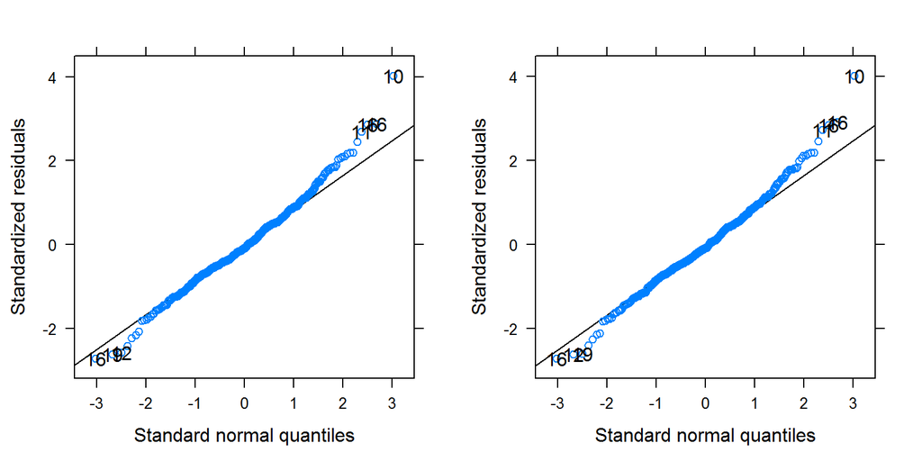

```r
qqp_21 <- qqmath(m_fp_con_21$full_model, id = 0.01, idLabels = as.character(drp_tt$P.s))
qqp_22 <- qqmath(m_fp_con_23$full_model, id = 0.01, idLabels = as.character(drp_tt$P.s))
grid.arrange(qqp_21, qqp_22, ncol = 2)
```

Furthermore, the maximally reduced model shows a significant effect of `Accepts`, the other models only marginally.

```r
nice(m_fp_con_21)
```

```
## Mixed Model Anova Table (Type 3 tests, KR-method)
##
## Model: log_con ~ Accepts + (Accepts | P.s) + (Fit | Item)
## Data: drp_tt
##    Effect       df      F p.value
## 1 Accepts 1, 16.60 4.12 +     .06
## ---
## Signif. codes:  0 '***' 0.001 '**' 0.01 '*' 0.05 '+' 0.1 ' ' 1
```

```r
nice(m_fp_con_22)
```

```
## Mixed Model Anova Table (Type 3 tests, KR-method)
##
## Model: log_con ~ Accepts + (Accepts | P.s) + (Fit || Item)
## Data: drp_tt
##    Effect       df      F p.value
## 1 Accepts 1, 16.38 4.33 +     .05
## ---
## Signif. codes:  0 '***' 0.001 '**' 0.01 '*' 0.05 '+' 0.1 ' ' 1
```

```r
nice(m_fp_con_23)
```

```
## Mixed Model Anova Table (Type 3 tests, KR-method)
##
## Model: log_con ~ Accepts + (Accepts | P.s) + (1 | Item)
## Data: drp_tt
##    Effect       df      F p.value
## 1 Accepts 1, 36.07 4.37 *     .04
## ---
## Signif. codes:  0 '***' 0.001 '**' 0.01 '*' 0.05 '+' 0.1 ' ' 1
```

### With Accepts (log-transformed RTs and reduced data set)

We remove a few data points that are outliers according to the QQ-plot.

```r
outlier_ids <- c(10, 11, 16)
n_outliers <-  c(1,  2,  3)
outlier_rows <- unlist(lapply(seq_along(outlier_ids), function(x) {
  tmp <- drp_tt[ drp_tt$P.s == outlier_ids[x], "log_con", drop=FALSE ]
  as.numeric(rownames(tmp)[order(tmp, decreasing = TRUE)[seq_len(n_outliers[x])]])
  }))

drp_tt2 <- drp_tt[-outlier_rows,]
```

We then start again with the maximal model.

```r
m_con_ar_1 <- mixed(log_con ~ Accepts + (Accepts|P.s) + (Fit| Item),
                           drp_tt2, progress = FALSE)
```

```
## Contrasts set to contr.sum for the following variables: P.s, Fit, Item
```

```
## Numerical variables NOT centered on 0 (i.e., interpretation of all main effects might be difficult if in interactions): Accepts
```

```r
summary(m_con_ar_1)
```

```
## Linear mixed model fit by REML ['merModLmerTest']
## Formula: log_con ~ Accepts + (Accepts | P.s) + (Fit | Item)
##    Data: drp_tt2
##
## REML criterion at convergence: 424
##
## Scaled residuals:
##      Min       1Q   Median       3Q      Max
## -2.82577 -0.60453 -0.06922  0.62153  2.61923
##
## Random effects:
##  Groups   Name        Variance  Std.Dev. Corr
##  P.s      (Intercept) 0.0999399 0.31613
##           Accepts     0.0103499 0.10173  -0.83
##  Item     (Intercept) 0.0662660 0.25742
##           Fit1        0.0004455 0.02111  1.00
##  Residual             0.1277024 0.35735
## Number of obs: 400, groups:  P.s, 24; Item, 17
##
## Fixed effects:
##             Estimate Std. Error t value
## (Intercept)  0.13205    0.14608   0.904
## Accepts     -0.08098    0.03524  -2.298
##
## Correlation of Fixed Effects:
##         (Intr)
## Accepts -0.853
```

We remove the correlations among the by-item random effects.

```r
m_con_ar_2 <- mixed(log_con ~ Accepts + (Accepts|P.s) + (Fit || Item),
                           drp_tt2, progress = FALSE, expand_re = TRUE)
```

```
## Contrasts set to contr.sum for the following variables: P.s, Fit, Item
```

```
## Numerical variables NOT centered on 0 (i.e., interpretation of all main effects might be difficult if in interactions): Accepts
```

```r
summary(m_con_ar_2)
```

```
## Linear mixed model fit by REML ['merModLmerTest']
## Formula: log_con ~ Accepts + (1 + re1.Accepts | P.s) + ((1 | Item) + (0 +
##     re2.Fit1 | Item))
##    Data: drp_tt2
##
## REML criterion at convergence: 425.2
##
## Scaled residuals:
##      Min       1Q   Median       3Q      Max
## -2.87388 -0.58654 -0.06433  0.63331  2.61872
##
## Random effects:
##  Groups   Name        Variance Std.Dev. Corr
##  P.s      (Intercept) 0.10534  0.3246
##           re1.Accepts 0.01074  0.1036   -0.84
##  Item     (Intercept) 0.06642  0.2577
##  Item.1   re2.Fit1    0.00000  0.0000
##  Residual             0.12806  0.3579
## Number of obs: 400, groups:  P.s, 24; Item, 17
##
## Fixed effects:
##             Estimate Std. Error t value
## (Intercept)  0.13735    0.15656   0.877
## Accepts     -0.08118    0.03491  -2.325
##
## Correlation of Fixed Effects:
##         (Intr)
## Accepts -0.856
```

We now also remove the random slope estimated to be zero.

```r
m_con_ar_3 <- mixed(log_con ~ Accepts + (Accepts|P.s) + (1 | Item),
                           drp_tt2, progress = FALSE, expand_re = FALSE)
```

```
## Contrasts set to contr.sum for the following variables: P.s, Item
```

```
## Numerical variables NOT centered on 0 (i.e., interpretation of all main effects might be difficult if in interactions): Accepts
```

```r
summary(m_con_ar_3)
```

```
## Linear mixed model fit by REML ['merModLmerTest']
## Formula: log_con ~ Accepts + (Accepts | P.s) + (1 | Item)
##    Data: drp_tt2
##
## REML criterion at convergence: 425.2
##
## Scaled residuals:
##      Min       1Q   Median       3Q      Max
## -2.87388 -0.58654 -0.06433  0.63331  2.61872
##
## Random effects:
##  Groups   Name        Variance Std.Dev. Corr
##  P.s      (Intercept) 0.10534  0.3246
##           Accepts     0.01074  0.1036   -0.84
##  Item     (Intercept) 0.06642  0.2577
##  Residual             0.12806  0.3579
## Number of obs: 400, groups:  P.s, 24; Item, 17
##
## Fixed effects:
##             Estimate Std. Error t value
## (Intercept)  0.13735    0.15656   0.877
## Accepts     -0.08118    0.03491  -2.325
##
## Correlation of Fixed Effects:
##         (Intr)
## Accepts -0.856
```

```r
anova(m_con_ar_1, m_con_ar_2, m_con_ar_3)
```

```
## Data: drp_tt2
## Models:
## m_con_ar_3: log_con ~ Accepts + (Accepts | P.s) + (1 | Item)
## m_con_ar_2: log_con ~ Accepts + (1 + re1.Accepts | P.s) + ((1 | Item) + (0 +
## m_con_ar_2:     re2.Fit1 | Item))
## m_con_ar_1: log_con ~ Accepts + (Accepts | P.s) + (Fit | Item)
##            Df   AIC    BIC logLik deviance  Chisq Chi Df Pr(>Chisq)
## m_con_ar_3  7 439.2 467.14 -212.6    425.2
## m_con_ar_2  8 441.2 473.14 -212.6    425.2 0.0000      1     1.0000
## m_con_ar_1  9 442.0 477.92 -212.0    424.0 1.2039      1     0.2726
```

The best model appears to be the reduced model. In addition, the QQ-plots shows comparatively mild violations.

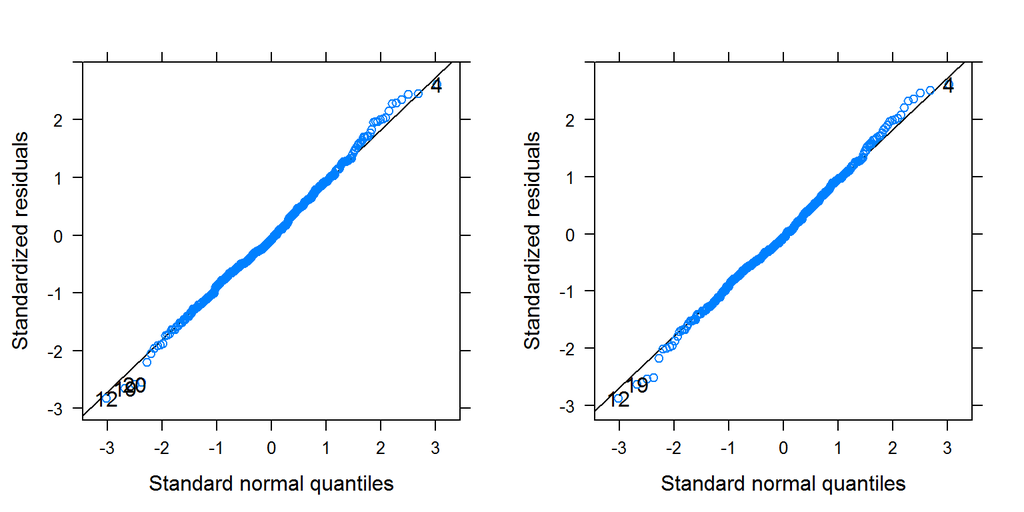

```r
qqp_21 <- qqmath(m_con_ar_1$full_model, id = 0.01, idLabels = as.character(drp_tt2$P.s))
qqp_22 <- qqmath(m_con_ar_3$full_model, id = 0.01, idLabels = as.character(drp_tt2$P.s))
grid.arrange(qqp_21, qqp_22, ncol = 2)
```

Furthermore, now all models show a significant effect of `Accepts`.

```r
nice(m_con_ar_1)
```

```
## Mixed Model Anova Table (Type 3 tests, KR-method)
##
## Model: log_con ~ Accepts + (Accepts | P.s) + (Fit | Item)
## Data: drp_tt2
##    Effect       df      F p.value
## 1 Accepts 1, 19.18 5.02 *     .04
## ---
## Signif. codes:  0 '***' 0.001 '**' 0.01 '*' 0.05 '+' 0.1 ' ' 1
```

```r
nice(m_con_ar_2)
```

```
## Mixed Model Anova Table (Type 3 tests, KR-method)
##
## Model: log_con ~ Accepts + (Accepts | P.s) + (Fit || Item)
## Data: drp_tt2
##    Effect       df      F p.value
## 1 Accepts 1, 18.69 5.31 *     .03
## ---
## Signif. codes:  0 '***' 0.001 '**' 0.01 '*' 0.05 '+' 0.1 ' ' 1
```

```r
nice(m_con_ar_3)
```

```
## Mixed Model Anova Table (Type 3 tests, KR-method)
##
## Model: log_con ~ Accepts + (Accepts | P.s) + (1 | Item)
## Data: drp_tt2
##    Effect       df      F p.value
## 1 Accepts 1, 33.18 5.34 *     .03
## ---
## Signif. codes:  0 '***' 0.001 '**' 0.01 '*' 0.05 '+' 0.1 ' ' 1
```

## Spillover

### With Accepts (log-transformed RTs)

```r
m_fp_spill_a_1 <- mixed(log_spill ~ Accepts + (Accepts|P.s) + (Fit| Item), drp_tt, progress = FALSE)
```

```
## Contrasts set to contr.sum for the following variables: P.s, Fit, Item
```

```
## Numerical variables NOT centered on 0 (i.e., interpretation of all main effects might be difficult if in interactions): Accepts
```

```r
summary(m_fp_spill_a_1)
```

```
## Linear mixed model fit by REML ['merModLmerTest']
## Formula: log_spill ~ Accepts + (Accepts | P.s) + (Fit | Item)
##    Data: drp_tt
##
## REML criterion at convergence: 344.5
##
## Scaled residuals:
##     Min      1Q  Median      3Q     Max
## -3.2609 -0.5022  0.0421  0.5950  2.7932
##
## Random effects:
##  Groups   Name        Variance  Std.Dev. Corr
##  P.s      (Intercept) 9.176e-02 0.302913
##           Accepts     1.786e-04 0.013365 -1.00
##  Item     (Intercept) 4.181e-02 0.204471
##           Fit1        6.806e-06 0.002609 1.00
##  Residual             1.066e-01 0.326562
## Number of obs: 406, groups:  P.s, 24; Item, 17
##
## Fixed effects:
##             Estimate Std. Error t value
## (Intercept)  0.78560    0.13678   5.744
## Accepts     -0.01284    0.02478  -0.518
##
## Correlation of Fixed Effects:
##         (Intr)
## Accepts -0.851
```

Again we extreme correlations at the boundary of the parameter space for the by-participant and by-item random-effects parameters and we refit the model without these correlations.

```r
m_fp_spill_a_2 <- mixed(log_spill ~ Accepts + (Accepts||P.s) + (Fit||Item), drp_tt, expand_re = TRUE, progress = FALSE)
```

```
## Contrasts set to contr.sum for the following variables: P.s, Fit, Item
```

```
## Numerical variables NOT centered on 0 (i.e., interpretation of all main effects might be difficult if in interactions): Accepts
```

```r
summary(m_fp_spill_a_2)
```

```
## Linear mixed model fit by REML ['merModLmerTest']
## Formula: log_spill ~ Accepts + ((1 | P.s) + (0 + re1.Accepts | P.s)) +
##     ((1 | Item) + (0 + re2.Fit1 | Item))
##    Data: drp_tt
##
## REML criterion at convergence: 344.9
##
## Scaled residuals:
##     Min      1Q  Median      3Q     Max
## -3.2545 -0.5085  0.0326  0.5899  2.8307
##
## Random effects:
##  Groups   Name        Variance Std.Dev.
##  P.s      (Intercept) 0.05870  0.2423
##  P.s.1    re1.Accepts 0.00000  0.0000
##  Item     (Intercept) 0.04155  0.2038
##  Item.1   re2.Fit1    0.00000  0.0000
##  Residual             0.10678  0.3268
## Number of obs: 406, groups:  P.s, 24; Item, 17
##
## Fixed effects:
##             Estimate Std. Error t value
## (Intercept)  0.78018    0.13299   5.867
## Accepts     -0.01153    0.02464  -0.468
##
## Correlation of Fixed Effects:
##         (Intr)
## Accepts -0.842
```

And the by-item random slope is now estimated at zero, we consequently refit the model without this parameters.

```r
m_fp_spill_a_3 <- mixed(log_spill ~ Accepts + (1|P.s) + (1| Item), drp_tt, expand_re = TRUE, progress = FALSE)
```

```
## Contrasts set to contr.sum for the following variables: P.s, Item
```

```
## Numerical variables NOT centered on 0 (i.e., interpretation of all main effects might be difficult if in interactions): Accepts
```

```r
summary(m_fp_spill_a_3)
```

```
## Linear mixed model fit by REML ['merModLmerTest']
## Formula: log_spill ~ Accepts + (1 | P.s) + (1 | Item)
##    Data: drp_tt
##
## REML criterion at convergence: 344.9
##
## Scaled residuals:
##     Min      1Q  Median      3Q     Max
## -3.2545 -0.5085  0.0326  0.5899  2.8307
##
## Random effects:
##  Groups   Name        Variance Std.Dev.
##  P.s      (Intercept) 0.05870  0.2423
##  Item     (Intercept) 0.04155  0.2038
##  Residual             0.10678  0.3268
## Number of obs: 406, groups:  P.s, 24; Item, 17
##
## Fixed effects:
##             Estimate Std. Error t value
## (Intercept)  0.78018    0.13299   5.867
## Accepts     -0.01153    0.02464  -0.468
##
## Correlation of Fixed Effects:
##         (Intr)
## Accepts -0.842
```

This model seems reasonable and provides basically the same account as the first model.

```r
anova(m_fp_spill_a_1, m_fp_spill_a_2, m_fp_spill_a_3)
```

```
## Data: drp_tt
## Models:
## m_fp_spill_a_3: log_spill ~ Accepts + (1 | P.s) + (1 | Item)
## m_fp_spill_a_2: log_spill ~ Accepts + ((1 | P.s) + (0 + re1.Accepts | P.s)) +
## m_fp_spill_a_2:     ((1 | Item) + (0 + re2.Fit1 | Item))
## m_fp_spill_a_1: log_spill ~ Accepts + (Accepts | P.s) + (Fit | Item)
##                Df    AIC    BIC  logLik deviance  Chisq Chi Df Pr(>Chisq)
## m_fp_spill_a_3  5 354.89 374.92 -172.44   344.89
## m_fp_spill_a_2  7 358.89 386.93 -172.44   344.89 0.0000      2     1.0000
## m_fp_spill_a_1  9 362.51 398.57 -172.25   344.51 0.3778      2     0.8279
```

```r
optimal_spill_tt <- m_fp_spill_a_3
```

The QQ-plot of both models again shows considerable departure from normality for small RTs.

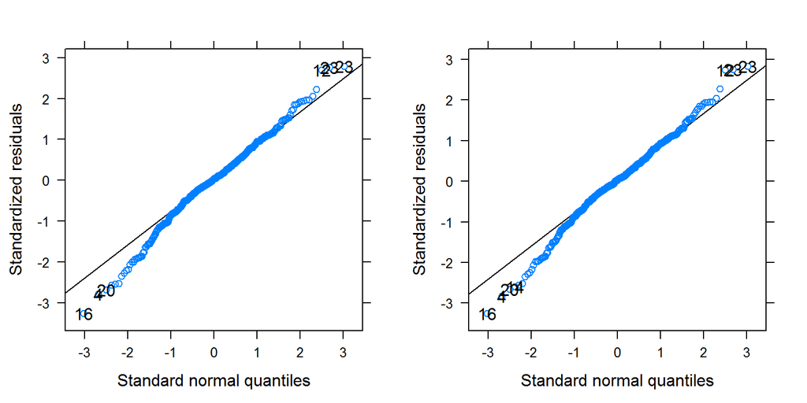

```r
qqp_m1 <- qqmath(m_fp_spill_a_1$full_model, id = 0.01, idLabels = as.character(drp_tt$P.s))
qqp_m2 <- qqmath(m_fp_spill_a_3$full_model, id = 0.01, idLabels = as.character(drp_tt$P.s))
grid.arrange(qqp_m1, qqp_m2, ncol = 2)
```

The effect of `Accepts` is not significant.

```r
nice(m_fp_spill_a_1)
```

```
## Mixed Model Anova Table (Type 3 tests, KR-method)
##
## Model: log_spill ~ Accepts + (Accepts | P.s) + (Fit | Item)
## Data: drp_tt
##    Effect       df    F p.value
## 1 Accepts 1, 12.30 0.25     .63
## ---
## Signif. codes:  0 '***' 0.001 '**' 0.01 '*' 0.05 '+' 0.1 ' ' 1
```

```r
nice(m_fp_spill_a_3)
```

```
## Mixed Model Anova Table (Type 3 tests, KR-method)
##
## Model: log_spill ~ Accepts + (1 | P.s) + (1 | Item)
## Data: drp_tt
##    Effect        df    F p.value
## 1 Accepts 1, 380.81 0.22     .64
## ---
## Signif. codes:  0 '***' 0.001 '**' 0.01 '*' 0.05 '+' 0.1 ' ' 1
```

## With Accept (reduced data set)

We remove a few data points that are outliers according to the QQ-plot.

```r
outlier_ids <- c(12, 23)
n_outliers <-  c(2,  4)
outlier_rows <- unlist(lapply(seq_along(outlier_ids), function(x) {
  tmp <- drp_tt[ drp_tt$P.s == outlier_ids[x], "log_con", drop=FALSE ]
  as.numeric(rownames(tmp)[order(tmp, decreasing = TRUE)[seq_len(n_outliers[x])]])
  }))

outlier_ids <- c(16, 4, 20)
n_outliers <-  c(3,  1, 1)
outlier_rows2 <- unlist(lapply(seq_along(outlier_ids), function(x) {
  tmp <- drp_tt[ drp_tt$P.s == outlier_ids[x], "log_con", drop=FALSE ]
  as.numeric(rownames(tmp)[order(tmp, decreasing = FALSE)[seq_len(n_outliers[x])]])
  }))

drp_tt2 <- drp_tt[-c(outlier_rows, outlier_rows2),]
```

Finally we again use the reduced data set.

```r
m_fp_spill_lambert_a_1 <- mixed(log_spill ~ Accepts + (Accepts|P.s) + (Fit| Item), drp_tt2, progress = FALSE)
```

```
## Contrasts set to contr.sum for the following variables: P.s, Fit, Item
```

```
## Numerical variables NOT centered on 0 (i.e., interpretation of all main effects might be difficult if in interactions): Accepts
```

```r
summary(m_fp_spill_lambert_a_1)
```

```
## Linear mixed model fit by REML ['merModLmerTest']
## Formula: log_spill ~ Accepts + (Accepts | P.s) + (Fit | Item)
##    Data: drp_tt2
##
## REML criterion at convergence: 294.9
##
## Scaled residuals:
##      Min       1Q   Median       3Q      Max
## -2.75932 -0.53034  0.01583  0.59849  2.92718
##
## Random effects:
##  Groups   Name        Variance  Std.Dev. Corr
##  P.s      (Intercept) 1.034e-01 0.321564
##           Accepts     1.750e-04 0.013228 -1.00
##  Item     (Intercept) 3.827e-02 0.195635
##           Fit1        2.309e-05 0.004806 1.00
##  Residual             9.433e-02 0.307135
## Number of obs: 395, groups:  P.s, 24; Item, 17
##
## Fixed effects:
##             Estimate Std. Error t value
## (Intercept)  0.83985    0.13218   6.354
## Accepts     -0.02254    0.02357  -0.956
##
## Correlation of Fixed Effects:
##         (Intr)
## Accepts -0.834
```

We again remove the correlations.

```r
m_fp_spill_lambert_a_2 <- mixed(log_spill ~ Accepts + (Accepts||P.s) + (Fit || Item), drp_tt2, progress = FALSE, expand_re = TRUE)
```

```
## Contrasts set to contr.sum for the following variables: P.s, Fit, Item
```

```
## Numerical variables NOT centered on 0 (i.e., interpretation of all main effects might be difficult if in interactions): Accepts
```

```r
summary(m_fp_spill_lambert_a_2)
```

```
## Linear mixed model fit by REML ['merModLmerTest']
## Formula: log_spill ~ Accepts + ((1 | P.s) + (0 + re1.Accepts | P.s)) +
##     ((1 | Item) + (0 + re2.Fit1 | Item))
##    Data: drp_tt2
##
## REML criterion at convergence: 295.4
##
## Scaled residuals:
##      Min       1Q   Median       3Q      Max
## -2.78910 -0.54332  0.02046  0.59558  2.89380
##
## Random effects:
##  Groups   Name        Variance Std.Dev.
##  P.s      (Intercept) 0.06845  0.2616
##  P.s.1    re1.Accepts 0.00000  0.0000
##  Item     (Intercept) 0.03797  0.1949
##  Item.1   re2.Fit1    0.00000  0.0000
##  Residual             0.09449  0.3074
## Number of obs: 395, groups:  P.s, 24; Item, 17
##
## Fixed effects:
##             Estimate Std. Error t value
## (Intercept)  0.83247    0.12888   6.459
## Accepts     -0.02081    0.02339  -0.890
##
## Correlation of Fixed Effects:
##         (Intr)
## Accepts -0.824
```

Now the random slopes are estimated to be virtually zero, we consequently refit the model without this parameter.

```r
m_fp_spill_lambert_a_3 <- mixed(log_spill ~ Accepts + (1|P.s) + (1| Item), drp_tt2, progress = FALSE, expand_re = TRUE)
```

```
## Contrasts set to contr.sum for the following variables: P.s, Item
```

```
## Numerical variables NOT centered on 0 (i.e., interpretation of all main effects might be difficult if in interactions): Accepts
```

```r
summary(m_fp_spill_lambert_a_3)
```

```
## Linear mixed model fit by REML ['merModLmerTest']
## Formula: log_spill ~ Accepts + (1 | P.s) + (1 | Item)
##    Data: drp_tt2
##
## REML criterion at convergence: 295.4
##
## Scaled residuals:
##      Min       1Q   Median       3Q      Max
## -2.78910 -0.54332  0.02046  0.59558  2.89380
##
## Random effects:
##  Groups   Name        Variance Std.Dev.
##  P.s      (Intercept) 0.06845  0.2616
##  Item     (Intercept) 0.03797  0.1949
##  Residual             0.09449  0.3074
## Number of obs: 395, groups:  P.s, 24; Item, 17
##
## Fixed effects:
##             Estimate Std. Error t value
## (Intercept)  0.83247    0.12888   6.459
## Accepts     -0.02081    0.02339  -0.890
##
## Correlation of Fixed Effects:
##         (Intr)
## Accepts -0.824
```

Again the final model appears to be the optimal model.

```r
anova(m_fp_spill_lambert_a_1, m_fp_spill_lambert_a_2, m_fp_spill_lambert_a_3)
```

```
## Data: drp_tt2
## Models:
## m_fp_spill_lambert_a_3: log_spill ~ Accepts + (1 | P.s) + (1 | Item)
## m_fp_spill_lambert_a_2: log_spill ~ Accepts + ((1 | P.s) + (0 + re1.Accepts | P.s)) +
## m_fp_spill_lambert_a_2:     ((1 | Item) + (0 + re2.Fit1 | Item))
## m_fp_spill_lambert_a_1: log_spill ~ Accepts + (Accepts | P.s) + (Fit | Item)
##                        Df    AIC    BIC  logLik deviance Chisq Chi Df
## m_fp_spill_lambert_a_3  5 305.35 325.25 -147.68   295.35
## m_fp_spill_lambert_a_2  7 309.35 337.20 -147.68   295.35 0.000      2
## m_fp_spill_lambert_a_1  9 312.91 348.72 -147.45   294.91 0.445      2
##                        Pr(>Chisq)
## m_fp_spill_lambert_a_3
## m_fp_spill_lambert_a_2     1.0000
## m_fp_spill_lambert_a_1     0.8005
```

The QQ-plot now still shows violations at the edges.

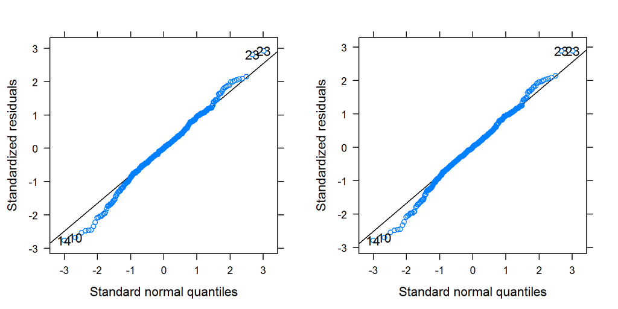

```r
qqp_m1 <- qqmath(m_fp_spill_lambert_a_1$full_model, id = 0.01, idLabels = as.character(drp_tt2$P.s))
qqp_m2 <- qqmath(m_fp_spill_lambert_a_3$full_model, id = 0.01, idLabels = as.character(drp_tt2$P.s))
grid.arrange(qqp_m1, qqp_m2, ncol = 2)
```

The effect of `Accepts` remains not significant.

```r
nice(m_fp_spill_lambert_a_1)
```

```
## Mixed Model Anova Table (Type 3 tests, KR-method)
##
## Model: log_spill ~ Accepts + (Accepts | P.s) + (Fit | Item)
## Data: drp_tt2
##    Effect       df    F p.value
## 1 Accepts 1, 12.10 0.85     .37
## ---
## Signif. codes:  0 '***' 0.001 '**' 0.01 '*' 0.05 '+' 0.1 ' ' 1
```

```r
nice(m_fp_spill_lambert_a_3)
```

```
## Mixed Model Anova Table (Type 3 tests, KR-method)
##
## Model: log_spill ~ Accepts + (1 | P.s) + (1 | Item)
## Data: drp_tt2
##    Effect        df    F p.value
## 1 Accepts 1, 370.03 0.78     .38
## ---
## Signif. codes:  0 '***' 0.001 '**' 0.01 '*' 0.05 '+' 0.1 ' ' 1
```

# Optimal Models

First Pass Reading Time: Consequent

| Effect | df | F | p.value |
| --- | --- | --- | --- |
| Accepts | 1, 362.78 | 0.52 | .47 |

First Pass Reading Time: Spillover

| Effect | df | F | p.value |
| --- | --- | --- | --- |
| Accepts | 1, 17.11 | 0.35 | .56 |

First Pass Regression Out: Consequent

| Effect | df | Chisq | p.value |
| --- | --- | --- | --- |
| Accepts | 1 | 4.70 * | .03 |

| Effect | df | Chisq | p.value |
| --- | --- | --- | --- |
| Accepts | 1 | 4.76 * | .03 |

Regression Path Times: Consequent

| Effect | df | F | p.value |
| --- | --- | --- | --- |
| Accepts | 1, 17.55 | 5.90 * | .03 |

Regression Path Times: Spillover

| Effect | df | F | p.value |
| --- | --- | --- | --- |
| Accepts | 1, 368.21 | 5.78 * | .02 |

Total Reading Times: Consequent

| Effect | df | F | p.value |
| --- | --- | --- | --- |
| Accepts | 1, 36.07 | 4.37 * | .04 |

Total Reading Times: Spillover

| Effect | df | F | p.value |
| --- | --- | --- | --- |
| Accepts | 1, 380.81 | 0.22 | .64 |

### Summary All Models

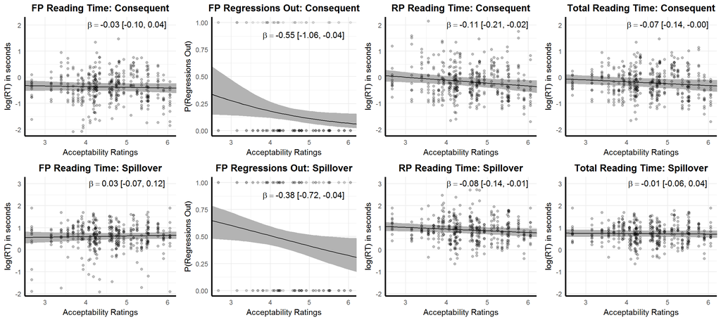

```r
min_con <- c(-2.25, 2.3)
min_spill <- c(-2.1, 3.3)
ylim_bin <- c(-0.05,1.05)
xvar <- seq(1, 7, by = 0.1)

alpha_1 <- 0.25
alpha_2 <- 0.05

xlab_text <- "Acceptability Ratings"

tt <- Effect("Accepts", optimal_con_fp$full_model, xlevels = list(Accepts = xvar))
tmp_df <- data.frame(x = tt$variables$Accepts$levels, min = tt$lower, max = tt$upper, fit = tt$fit)
size_anno <- 4

make_beta_string <- function(model) {
  #browser()
  df <- summary(lstrends(model, specs = ~1, var = "Accepts"))
  paste0("beta", "== '",
  formatC(df$Accepts.trend[1], digits = 2, format = "f"), " [",
  formatC(df[1,5], digits = 2, format = "f"), ", ",
  formatC(df[1,6], digits = 2, format = "f"), "]'"
  )
}
lsm.options(lmer.df = "Kenward-Roger")

pfp_con <- ggplot() +
  geom_ribbon(data = tmp_df, aes(x = x, ymin = min, ymax = max), fill = "grey70") +
  geom_point(data = drp_fp, mapping = aes(x = Accepts, y = log_con), alpha = alpha_1) +
  geom_line(data = tmp_df, mapping = aes(x = x, y = fit)) +
  coord_cartesian(xlim = c(2.5, 6.2), ylim = min_con, expand = FALSE) +
  xlab(xlab_text) + ylab("log(RT) in seconds") +
  ggtitle("FP Reading Time: Consequent") +
  annotate("text", x = 5, y = 2,
           label = make_beta_string(optimal_con_fp), parse = TRUE, size = size_anno,
           family="open_sans")


tt <- Effect("Accepts", optimal_spill_fp$full_model, xlevels = list(Accepts = xvar))
tmp_df <- data.frame(x = tt$variables$Accepts$levels, min = tt$lower, max = tt$upper, fit = tt$fit)
pfp_spill <-
  ggplot() +
  geom_ribbon(data = tmp_df, aes(x = x, ymin = min, ymax = max), fill = "grey70") +
  geom_point(data = drp_fp, mapping = aes(x = Accepts, y = log_spill), alpha = alpha_1) +
  geom_line(data = tmp_df, mapping = aes(x = x, y = fit)) +
  coord_cartesian(xlim = c(2.5, 6.2), ylim = min_spill, expand = FALSE) +
  xlab(xlab_text) + ylab("log(RT) in seconds") +
  ggtitle("FP Reading Time: Spillover") +
  annotate("text", x = 5, y = 3,
           label = make_beta_string(optimal_spill_fp), parse = TRUE, size = size_anno,
           family="open_sans")

tt <- Effect("Accepts", optimal_con_ro$full_model, xlevels = list(Accepts = xvar))
tmp_df <- data.frame(x = tt$variables$Accepts$levels, min = tt$lower, max = tt$upper, fit = tt$fit)
pro_con <- ggplot() +
  geom_ribbon(data = tmp_df, aes(x = x,
                                 ymin = binomial()$linkinv(min),
                                 ymax = binomial()$linkinv(max)), fill = "grey70") +
  geom_point(data = drp_ro, aes(x = Accepts, y = Consequent), alpha = alpha_2) +
  geom_line(data = tmp_df, mapping = aes(x = x, y = binomial()$linkinv(fit))) +
  coord_cartesian(xlim = c(2.5, 6.2), ylim = ylim_bin, expand = FALSE) +
  xlab(xlab_text) + ylab("P(Regressions Out)") +
  ggtitle("FP Regressions Out: Consequent") +
  annotate("text", x = 4.85, y = 0.88,
           label = make_beta_string(optimal_con_ro), parse = TRUE, size = size_anno,
           family="open_sans")

tt <- Effect("Accepts", optimal_spill_ro$full_model, xlevels = list(Accepts = xvar))
tmp_df <- data.frame(x = tt$variables$Accepts$levels, min = tt$lower, max = tt$upper, fit = tt$fit)
pro_spill <-
  ggplot() +
  geom_ribbon(data = tmp_df, aes(x = x,
                                 ymin = binomial()$linkinv(min),
                                 ymax = binomial()$linkinv(max)), fill = "grey70") +
  geom_point(data = drp_ro, aes(x = Accepts, y = spillover), alpha = alpha_2) +
  geom_line(data = tmp_df, mapping = aes(x = x, y = binomial()$linkinv(fit))) +
  coord_cartesian(xlim = c(2.5, 6.2), ylim = ylim_bin, expand = FALSE) +
  xlab(xlab_text) + ylab("P(Regressions Out)") +
  ggtitle("FP Regressions Out: Spillover") +
  annotate("text", x = 4.85, y = 0.88,
           label = make_beta_string(optimal_spill_ro), parse = TRUE, size = size_anno,
           family="open_sans")


tt <- Effect("Accepts", optimal_con_rp$full_model, xlevels = list(Accepts = xvar))
tmp_df <- data.frame(x = tt$variables$Accepts$levels, min = tt$lower, max = tt$upper, fit = tt$fit)
prp_con <- ggplot() +
  geom_ribbon(data = tmp_df, aes(x = x, ymin = min, ymax = max), fill = "grey70") +
  geom_point(data = drp_rp, mapping = aes(x = Accepts, y = log_con), alpha = alpha_1) +
  geom_line(data = tmp_df, mapping = aes(x = x, y = fit)) +
  coord_cartesian(xlim = c(2.5, 6.2), ylim = min_con, expand = FALSE) +
  xlab(xlab_text) + ylab("log(RT) in seconds") +
  ggtitle("RP Reading Time: Consequent") +
  annotate("text", x = 5, y = 2,
           label = make_beta_string(optimal_con_rp), parse = TRUE, size = size_anno,
           family="open_sans")


tt <- Effect("Accepts", optimal_spill_rp$full_model, xlevels = list(Accepts = xvar))
tmp_df <- data.frame(x = tt$variables$Accepts$levels, min = tt$lower, max = tt$upper, fit = tt$fit)
prp_spill <-
  ggplot() +
  geom_ribbon(data = tmp_df, aes(x = x, ymin = min, ymax = max), fill = "grey70") +
  geom_point(data = drp_rp, mapping = aes(x = Accepts, y = log_spill), alpha = alpha_1) +
  geom_line(data = tmp_df, mapping = aes(x = x, y = fit)) +
  coord_cartesian(xlim = c(2.5, 6.2), ylim = min_spill, expand = FALSE) +
  xlab(xlab_text) + ylab("log(RT) in seconds") +
  ggtitle("RP Reading Time: Spillover") +
  annotate("text", x = 5, y = 3,
           label = make_beta_string(optimal_spill_rp), parse = TRUE, size = size_anno,
           family="open_sans")


tt <- Effect("Accepts", optimal_con_tt$full_model, xlevels = list(Accepts = xvar))
tmp_df <- data.frame(x = tt$variables$Accepts$levels, min = tt$lower, max = tt$upper, fit = tt$fit)
ptt_con <- ggplot() +
  geom_ribbon(data = tmp_df, aes(x = x, ymin = min, ymax = max), fill = "grey70") +
  geom_point(data = drp_tt, mapping = aes(x = Accepts, y = log_con), alpha = alpha_1) +
  geom_line(data = tmp_df, mapping = aes(x = x, y = fit)) +
  coord_cartesian(xlim = c(2.5, 6.2), ylim = min_con, expand = FALSE) +
  xlab(xlab_text) + ylab("log(RT) in seconds") +
  ggtitle("Total Reading Time: Consequent") +
  annotate("text", x = 5, y = 2,
           label = make_beta_string(optimal_con_tt), parse = TRUE, size = size_anno,
           family="open_sans")


tt <- Effect("Accepts", optimal_spill_tt$full_model, xlevels = list(Accepts = xvar))
tmp_df <- data.frame(x = tt$variables$Accepts$levels, min = tt$lower, max = tt$upper, fit = tt$fit)
ptt_spill <-
  ggplot() +
  geom_ribbon(data = tmp_df, aes(x = x, ymin = min, ymax = max), fill = "grey70") +
  geom_point(data = drp_tt, mapping = aes(x = Accepts, y = log_spill), alpha = alpha_1) +
  geom_line(data = tmp_df, mapping = aes(x = x, y = fit)) +
  coord_cartesian(xlim = c(2.5, 6.2), ylim = min_spill, expand = FALSE) +
  xlab(xlab_text) + ylab("log(RT) in seconds") +
  ggtitle("Total Reading Time: Spillover") +
  annotate("text", x = 5, y = 3,
           label = make_beta_string(optimal_spill_tt), parse = TRUE, size = size_anno,
           family="open_sans")


pp <- grid.arrange(pfp_con, pfp_spill, pro_con, pro_spill, prp_con, prp_spill, ptt_con, ptt_spill,  ncol = 4, as.table = FALSE)
```